# 07_PCA

# Load Data

```r
library("tidyverse")
```

## Load data

Data will be fetched from hbiostat from vanderbilt department of biostatistics.

```r
raw_dir <- "../data/_raw/"
data_file <- "prostate.rda"
data_loc <- "https://hbiostat.org/data/repo/"

if( !dir.exists(raw_dir) ){
  dir.create(path = raw_dir, recursive = TRUE)
}

if( !file.exists(str_c(raw_dir, data_file)) ){
  download.file(
    url = str_c(data_loc, data_file),
    destfile = str_c(raw_dir, data_file),
    mode = "wb")
}
load(file = str_c(raw_dir, data_file))
```

### Metadata

```r
data_dir <- "../data/"
meta_tsv_file <- "01_meta_dat_load.tsv"
if (!file.exists(str_c(data_dir, meta_tsv_file)) ) {
  prostate |>
    select(patno, stage, status, age, wt, pf, hx, sdate) |>
    write_tsv(file = str_c(data_dir, meta_tsv_file))
}
```

### Treatment data

```r
treatment_tsv_file <- "01_treatment_dat_load.tsv"
if (!file.exists(str_c(data_dir, treatment_tsv_file)) ) {
  prostate |>
  select(-stage, -status, -age, -wt, -pf, -hx, -sdate) |>
    write_tsv(file = str_c(data_dir, treatment_tsv_file))
}
```

# Tidying Data

```r
library("tidyverse")
source("99_proj_func.R")
set.seed(2025)
```

## A quick look

First we’ll take a quick look at the dataset to see how we can tidy it

```r
# Load the data saved in "01_load.qmd"
data_dir <- "../data/"
meta_df <- read_tsv(str_c(data_dir, "01_meta_dat_load.tsv"))
treatment_df <- read_tsv(str_c(data_dir, "01_treatment_dat_load.tsv"))
#Print random samples
meta_df |> slice_sample(n = 5) |> print()
```

```
# A tibble: 5 × 8
  patno stage status                     age    wt pf              hx sdate
  <dbl> <dbl> <chr>                    <dbl> <dbl> <chr>        <dbl> <date>
1   397     4 dead - prostatic ca         76    76 normal acti…     0 1978-08-10
2   460     4 dead - heart or vascular    75   124 normal acti…     0 1978-07-30
3   420     3 dead - heart or vascular    72   128 normal acti…     0 1978-09-12
4   410     4 alive                       71   104 normal acti…     0 1979-05-23
5   449     3 dead - heart or vascular    78   103 normal acti…     0 1978-08-07
```

```r
treatment_df |> slice_sample(n = 5) |> print()
```

```
# A tibble: 5 × 11
  patno rx              dtime   sbp   dbp ekg      hg    sz    sg       ap    bm
  <dbl> <chr>           <dbl> <dbl> <dbl> <chr> <dbl> <dbl> <dbl>    <dbl> <dbl>
1   279 5.0 mg estrogen    29    13     8 norm…  12.7    17    13 1000.        1
2   187 0.2 mg estrogen    67    16     6 hear…  13       4     9    0.400     0
3   266 5.0 mg estrogen    53    13     7 rhyt…  13.4    17    11  278.        1
4   461 0.2 mg estrogen    40    10     6 hear…  14.7     2    12    8.20      0
5   369 5.0 mg estrogen    52    16     8 old …  10       1     7    0.600     0
```

## Joining the tables

Both tables contain information about a patient based on the patient ID in the `patno` column. We perform an inner join based on `patno` to have all variables in one dataframe. If there are observations with no associated ID it will be discarded however this should not be the case and will be checked later.

```r
#Perform the inner join
full_df <- inner_join(x = meta_df,
                      y = treatment_df,
                      by = "patno")
full_df |> slice_sample(n = 5) |> print()
```

```
# A tibble: 5 × 18
  patno stage status    age    wt pf       hx sdate      rx    dtime   sbp   dbp
  <dbl> <dbl> <chr>   <dbl> <dbl> <chr> <dbl> <date>     <chr> <dbl> <dbl> <dbl>
1   460     4 dead -…    75   124 norm…     0 1978-07-30 1.0 …    30    15    10
2   388     4 dead -…    79    99 in b…     0 1978-03-29 0.2 …    11    16     8
3    27     4 alive      76    82 norm…     0 1977-11-09 plac…    69    12     8
4   472     3 dead -…    72   106 norm…     1 1978-12-12 0.2 …    33    13     8
5   379     4 alive      77    87 norm…     0 1977-05-31 plac…    75    11     6
# ℹ 6 more variables: ekg <chr>, hg <dbl>, sz <dbl>, sg <dbl>, ap <dbl>,
#   bm <dbl>
```

### Checking for lost observations

If everything is as expected the the number of observations in `full_df` should match the number in `meta_df` and `treatment_df` and the number of variables should be the sum of varibles in the two minus one as `patno` exists in both.

```r
cat("Size of meta_df:     ", dim(meta_df), "\n")
```

```
Size of meta_df:      502 8
```

```r
cat("Size of treatment_df:", dim(treatment_df), "\n")
```

```
Size of treatment_df: 502 11
```

```r
cat("Size of full_df:     ", dim(full_df))
```

```
Size of full_df:      502 18
```

As we can see, everything is as expected.

## Splitting columns

As seen in the random sample of `full_df` the status column contains both dead/alive status and cause of death. We will split these to two columns.

```r
full_df <- full_df |>
  separate(col = status,
           into = c("is_alive", "cause_of_death"),
           sep = " - ") |>
  mutate(is_alive = factor(is_alive))
full_df |> slice_sample(n = 5) |> save_and_show_table("intro_table_for_presentation")
```

```
# A tibble: 5 × 19
  patno stage is_alive cause_of_death     age    wt pf       hx sdate      rx
  <dbl> <dbl> <fct>    <chr>            <dbl> <dbl> <chr> <dbl> <date>     <chr>
1   373     3 dead     other specific …    76   116 norm…     1 1979-05-17 0.2 …
2   407     4 dead     prostatic ca        78    95 norm…     0 1978-12-06 plac…
3    59     3 dead     cerebrovascular     78   118 norm…     1 1979-03-02 0.2 …
4   395     4 dead     prostatic ca        81    98 norm…     1 1978-06-25 1.0 …
5   159     4 alive    <NA>                78   116 norm…     0 1979-05-21 0.2 …
# ℹ 9 more variables: dtime <dbl>, sbp <dbl>, dbp <dbl>, ekg <chr>, hg <dbl>,
#   sz <dbl>, sg <dbl>, ap <dbl>, bm <dbl>
```

We will also split the treatment variable into dosage and treatment group

```r
full_df <- full_df |>
  mutate("treatment" = case_when(str_detect(rx, "estrogen") ~ "estrogen",
                                 str_detect(rx, "placebo") ~ "placebo",
                                 TRUE ~ NA),
         dosage = as.numeric(str_extract(rx, "\\d+\\.\\d+")), #extract number dot number w regex
         dosage = as.numeric(replace_na(dosage, 0))
         ) |>
  select(-rx)
```

## Renaming variables

Some of the columns have somewhat non-descriptive names. For these new names will be assigned based on the information available at https://hbiostat.org/data/repo/cprostate.

```r
full_df <- full_df |> rename(patient_no = "patno",
                             weight = "wt",
                             performance = "pf",
                             medical_history = "hx",
                             study_date = "sdate",
                             follow_up_months = "dtime",
                             sys_blood_pressure= "sbp",
                             dia_blood_pressure = "dbp",
                             serum_hemoglobin = "hg",
                             size_of_primary_tumor = "sz",
                             combined_index = "sg",
                             bone_metastases = "bm",
                             serum_prostatic_acid_phosphatase = "ap")
```

## Data types

Finally we cast the `stage`, `is_alive` and `performance` variables to factors. `medical_history` and `bone_metastases` are cast to logical vectors.

```r
full_df <- full_df |> mutate(stage = factor(as.integer(stage), levels = c(1,2,3,4), ordered = TRUE),
                             cause_of_death = factor(cause_of_death),
                             performance = factor(performance),
                             ekg = factor(ekg),
                             medical_history = medical_history == 1,
                             bone_metastases = bone_metastases == 1) # convert to logical
```

## Overview

The `table1` package is used to generate a quick overview to ensure everything is as it should be

```r
table1::table1(full_df, x = formula(~stage + age + performance | is_alive + treatment))
```

|  | alive estrogen (N=116) | alive placebo (N=32) | dead estrogen (N=259) | dead placebo (N=95) | Overall estrogen (N=375) | Overall placebo (N=127) |
| --- | --- | --- | --- | --- | --- | --- |
| stage |  |  |  |  |  |  |
| 1 | 0 (0%) | 0 (0%) | 0 (0%) | 0 (0%) | 0 (0%) | 0 (0%) |
| 2 | 0 (0%) | 0 (0%) | 0 (0%) | 0 (0%) | 0 (0%) | 0 (0%) |
| 3 | 73 (62.9%) | 23 (71.9%) | 142 (54.8%) | 51 (53.7%) | 215 (57.3%) | 74 (58.3%) |
| 4 | 43 (37.1%) | 9 (28.1%) | 117 (45.2%) | 44 (46.3%) | 160 (42.7%) | 53 (41.7%) |
| age |  |  |  |  |  |  |
| Mean (SD) | 69.8 (7.33) | 71.5 (5.92) | 72.0 (7.19) | 71.8 (6.61) | 71.4 (7.30) | 71.7 (6.42) |
| Median [Min, Max] | 72.0 [49.0, 84.0] | 73.0 [55.0, 79.0] | 73.0 [48.0, 89.0] | 73.0 [50.0, 84.0] | 73.0 [48.0, 89.0] | 73.0 [50.0, 84.0] |
| Missing | 1 (0.9%) | 0 (0%) | 0 (0%) | 0 (0%) | 1 (0.3%) | 0 (0%) |
| performance |  |  |  |  |  |  |
| confined to bed | 0 (0%) | 0 (0%) | 2 (0.8%) | 0 (0%) | 2 (0.5%) | 0 (0%) |
| in bed < 50% daytime | 2 (1.7%) | 2 (6.3%) | 26 (10.0%) | 7 (7.4%) | 28 (7.5%) | 9 (7.1%) |
| in bed > 50% daytime | 2 (1.7%) | 0 (0%) | 6 (2.3%) | 5 (5.3%) | 8 (2.1%) | 5 (3.9%) |
| normal activity | 112 (96.6%) | 30 (93.8%) | 225 (86.9%) | 83 (87.4%) | 337 (89.9%) | 113 (89.0%) |

## Save the data to drive

```r
#save a compressed tsv
data_dir <- "../data/"
tidy_tsv_file <- "02_dat_tidy.tsv.gz"

full_df |> write_tsv(file = str_c(data_dir, tidy_tsv_file))
```

# Augment Data

## Load library

```r
library("tidyverse")
source("99_proj_func.R")
```

## Load data

Loading the prepared tidy data.

```r
data_dir <- "data/"
tidy_file <- "02_dat_tidy.tsv.gz"

full_df <- read_tsv("../data/02_dat_tidy.tsv.gz")
full_df |> slice_sample(n = 10)
```

```
# A tibble: 10 × 20
   patient_no stage is_alive cause_of_death          age weight performance
        <dbl> <dbl> <chr>    <chr>                 <dbl>  <dbl> <chr>
 1        142     3 dead     pulmonary embolus        83    115 normal activity
 2         37     4 dead     other specific non-ca    72     93 normal activity
 3        288     4 dead     heart or vascular        71    119 normal activity
 4         63     4 dead     prostatic ca             73    102 normal activity
 5        285     4 dead     prostatic ca             59    100 normal activity
 6        289     4 dead     prostatic ca             76     94 normal activity
 7        252     3 dead     heart or vascular        79     94 normal activity
 8        345     3 dead     prostatic ca             70     83 normal activity
 9        118     4 alive    <NA>                     73    106 normal activity
10         88     3 dead     other ca                 70     72 normal activity
# ℹ 13 more variables: medical_history <lgl>, study_date <date>,
#   follow_up_months <dbl>, sys_blood_pressure <dbl>, dia_blood_pressure <dbl>,
#   ekg <chr>, serum_hemoglobin <dbl>, size_of_primary_tumor <dbl>,
#   combined_index <dbl>, serum_prostatic_acid_phosphatase <dbl>,
#   bone_metastases <lgl>, treatment <chr>, dosage <dbl>
```

## Filtering out extreme AP values

Its noted on the Vanderbilt repo that some entries have extremely high AP values. Unfortunantly the explanation is no longer available. For this reason we choose to remove these rows entirely:

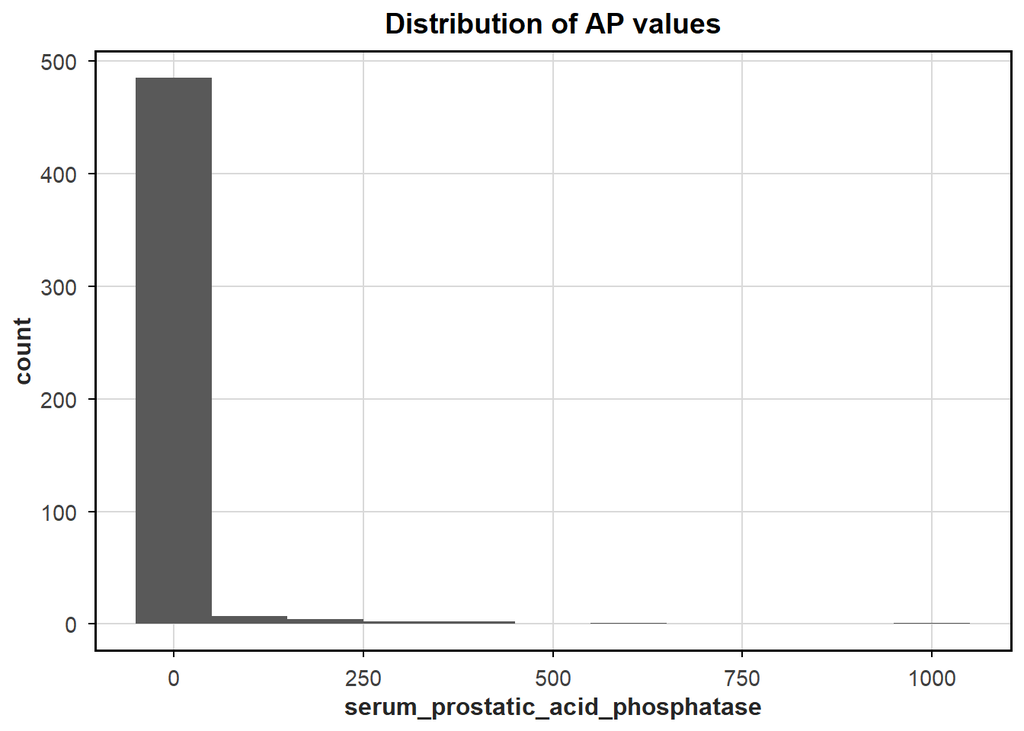

```r
full_df |>
  ggplot(aes(x=serum_prostatic_acid_phosphatase)) +
  geom_histogram(binwidth = 100) +
  labs(
    title = "Distribution of AP values"
  ) +
  best_theme()
```

Based on the plot we discard all entries with AP values above 250

```r
cutoff <- 250
full_df <- full_df |>
  filter(serum_prostatic_acid_phosphatase <= cutoff)
```

```r
full_df |> slice_sample(n = 10)
```

```
# A tibble: 10 × 20
   patient_no stage is_alive cause_of_death          age weight performance
        <dbl> <dbl> <chr>    <chr>                 <dbl>  <dbl> <chr>
 1        197     4 dead     respiratory disease      70     86 normal activity
 2        176     4 dead     heart or vascular        68    104 normal activity
 3        434     4 alive    <NA>                     56    135 normal activity
 4        377     4 dead     cerebrovascular          76     82 normal activity
 5        312     3 dead     other specific non-ca    70     78 normal activity
 6         60     3 dead     other ca                 60     99 normal activity
 7        323     3 dead     heart or vascular        72    100 normal activity
 8         16     3 dead     heart or vascular        87     81 in bed < 50% da…
 9        457     4 alive    <NA>                     77    106 normal activity
10        331     3 dead     heart or vascular        70     91 normal activity
# ℹ 13 more variables: medical_history <lgl>, study_date <date>,
#   follow_up_months <dbl>, sys_blood_pressure <dbl>, dia_blood_pressure <dbl>,
#   ekg <chr>, serum_hemoglobin <dbl>, size_of_primary_tumor <dbl>,
#   combined_index <dbl>, serum_prostatic_acid_phosphatase <dbl>,
#   bone_metastases <lgl>, treatment <chr>, dosage <dbl>
```

## Preparing data for modelling

Modelling tumor size vs other factors may pose an interesting investigation and see which factors may be important for tumor development in advanced stages. We need to first convert the columns that are not already numeric to a numeric representation. This can be done in a number of ways but to keep it similar we choose that the higher the number the worse for the potion. For example normal activity is assigned zero and low activity such as stuck in bed is assigned four.

```r
df_num <- full_df |>
  mutate(is_alive = case_when(is_alive == "alive" ~ 0,
                              is_alive == "dead" ~ 1),
         performance = case_when(performance == "normal activity" ~ 0,
                                 performance == "in bed < 50% daytime" ~ 1,
                                 performance == "in bed > 50% daytime" ~ 2,
                                 performance == "confined to bed" ~ 4),
         medical_history = as.numeric(medical_history),
         ekg = case_when(ekg == "normal" ~ 0,
                         ekg == "benign" ~ 1,
                         ekg == "heart block or conduction def" ~ 2,
                         ekg == "rhythmic disturb & electrolyte ch" ~ 3,
                         ekg == "old MI" ~ 4,
                         ekg == "recent MI" ~ 5,
                         ekg == "rhythmic disturb & electrolyte ch" ~ 6,
                         ekg == "heart strain" ~ 7),
         bone_metastases = as.numeric(bone_metastases),
         treatment = case_when(treatment == "placebo" ~ 0,
                               treatment == "estrogen" ~ 1)
         )
```

Similarly to the example available at https://r4bds.github.io/lab06.html we need a long version of the data where current variable is stored as an entry.

```r
df_long <- df_num |>
  select(c(patient_no,stage, age, weight, follow_up_months,
                        sys_blood_pressure, dia_blood_pressure,
                        serum_hemoglobin, serum_prostatic_acid_phosphatase,
                        combined_index, size_of_primary_tumor, is_alive, performance, medical_history,ekg, bone_metastases, treatment, dosage)) |>
  pivot_longer(cols = c(stage, age, weight, follow_up_months,
                        sys_blood_pressure, dia_blood_pressure,
                        serum_hemoglobin, serum_prostatic_acid_phosphatase,
                        combined_index, is_alive, performance, medical_history,ekg, bone_metastases, treatment, dosage),
               names_to = "variable",
               values_to = "value")

print(df_long |> slice_sample(n = 10))
```

```
# A tibble: 10 × 4
   patient_no size_of_primary_tumor variable         value
        <dbl>                 <dbl> <chr>            <dbl>
 1        231                     5 follow_up_months     0
 2         77                     5 is_alive             1
 3        270                    15 dosage               0
 4        264                    20 stage                4
 5         25                     6 treatment            1
 6        330                     8 age                 72
 7        170                     9 age                 73
 8        402                    25 combined_index      13
 9        461                     2 performance          0
10        225                    50 performance          0
```

For analysis nesting variables is required.

```r
df_long_nested <- df_long |>
  group_by(variable) |>
  nest()
df_long_nested |> head(10) |> print() #quick check
```

```
# A tibble: 10 × 2
# Groups:   variable [10]
   variable                         data
   <chr>                            <list>
 1 stage                            <tibble [496 × 3]>
 2 age                              <tibble [496 × 3]>
 3 weight                           <tibble [496 × 3]>
 4 follow_up_months                 <tibble [496 × 3]>
 5 sys_blood_pressure               <tibble [496 × 3]>
 6 dia_blood_pressure               <tibble [496 × 3]>
 7 serum_hemoglobin                 <tibble [496 × 3]>
 8 serum_prostatic_acid_phosphatase <tibble [496 × 3]>
 9 combined_index                   <tibble [496 × 3]>
10 is_alive                         <tibble [496 × 3]>
```

### Save this data

This data is saved as .Rdata to ensure that types are carried over

```r
save(df_long_nested, df_num, file = "../data/04_data_for_modelling.Rdata")
```

## Augment data for treatment class

On top of nesting variables, a data object with attributed treatment class is made. The MAP (Mean Arterial Pressure) variable is added to this set. MAP is the average blood pressure in a person’s arteries during one cardiac cycle (one heartbeat).

```r
augment_data <- full_df |>
  mutate(MAP = (sys_blood_pressure+ 2 *dia_blood_pressure) / 3,
         is_alive = case_when(is_alive == "alive" ~ 0,
                              is_alive == "dead" ~ 1),
         treatment_detail = case_when(
           treatment == "placebo" ~ "Placebo",
           treatment == "estrogen" & dosage == 0.2 ~ "0.2mg Estrogen",
           treatment == "estrogen" & dosage == 1.0 ~ "1.0mg Estrogen",
           treatment == "estrogen" & dosage == 5.0 ~ "5.0mg Estrogen",
           TRUE ~ NA_character_),
         treatment_detail = factor(treatment_detail,
                                   levels = c("Placebo",
                                              "0.2mg Estrogen",
                                              "1.0mg Estrogen",
                                              "5.0mg Estrogen")),)

augment_data |> slice_sample(n = 10)
```

```
# A tibble: 10 × 22
   patient_no stage is_alive cause_of_death       age weight performance
        <dbl> <dbl>    <dbl> <chr>              <dbl>  <dbl> <chr>
 1        439     3        0 <NA>                  71    105 normal activity
 2        308     3        1 prostatic ca          74     97 normal activity
 3        458     4        0 <NA>                  71    101 normal activity
 4         24     4        1 prostatic ca          56     95 normal activity
 5        282     4        1 prostatic ca          76     97 normal activity
 6        483     4        1 heart or vascular     72     83 normal activity
 7        467     3        1 heart or vascular     73    111 normal activity
 8        272     3        1 pulmonary embolus     72     82 normal activity
 9        313     3        1 unspecified non-ca    73    105 normal activity
10        431     4        1 prostatic ca          76     96 normal activity
# ℹ 15 more variables: medical_history <lgl>, study_date <date>,
#   follow_up_months <dbl>, sys_blood_pressure <dbl>, dia_blood_pressure <dbl>,
#   ekg <chr>, serum_hemoglobin <dbl>, size_of_primary_tumor <dbl>,
#   combined_index <dbl>, serum_prostatic_acid_phosphatase <dbl>,
#   bone_metastases <lgl>, treatment <chr>, dosage <dbl>, MAP <dbl>,
#   treatment_detail <fct>
```

### Saving treatment class data

```r
data_dir <- "../data/"
aug_tsv_file <- "03_dat_aug.tsv.gz"
augment_data |> write_tsv(file = str_c(data_dir,aug_tsv_file))
```

# Load libraries

```r
library("tidyverse")
library("viridis")
library("ggridges")
source("99_proj_func.R")
```

# Data description

This dataset is from Green and Bryar who have analysed data from a randomized clinical trial of prostate cancer paitients in stage 3 and 4. In this project the same data will be analysed

## Meta data

Below is the full prostate data set after tidying.

```r
prostate_tidy <- read_tsv("../data/02_dat_tidy.tsv.gz")
prostate_tidy
```

```
# A tibble: 502 × 20
   patient_no stage is_alive cause_of_death      age weight performance
        <dbl> <dbl> <chr>    <chr>             <dbl>  <dbl> <chr>
 1          1     3 alive    <NA>                 75     76 normal activity
 2          2     3 dead     other ca             54    116 normal activity
 3          3     3 dead     cerebrovascular      69    102 normal activity
 4          4     3 dead     cerebrovascular      75     94 in bed < 50% daytime
 5          5     3 alive    <NA>                 67     99 normal activity
 6          6     3 dead     prostatic ca         71     98 normal activity
 7          7     3 dead     heart or vascular    75    100 normal activity
 8          8     3 alive    <NA>                 73    114 normal activity
 9          9     3 alive    <NA>                 60    110 normal activity
10         10     3 alive    <NA>                 78    107 normal activity
# ℹ 492 more rows
# ℹ 13 more variables: medical_history <lgl>, study_date <date>,
#   follow_up_months <dbl>, sys_blood_pressure <dbl>, dia_blood_pressure <dbl>,
#   ekg <chr>, serum_hemoglobin <dbl>, size_of_primary_tumor <dbl>,
#   combined_index <dbl>, serum_prostatic_acid_phosphatase <dbl>,
#   bone_metastases <lgl>, treatment <chr>, dosage <dbl>
```

It contains data from 502 patients with each 20 variables that have been kept track of. The most important in this instance is; stage, combined stage index, cause of death, treatment, dosage and clinical measurements. These include: weight, age, medical history, systolic/diastolic blood pressure, ekg, serum hemoglobin, primary tumor size in cm<sup>2</sup>, serum prostatic acid phosphatase (PAP) and bone metastasis indicator. Distribution of these various parameters can be seen below.

## Stage distribution

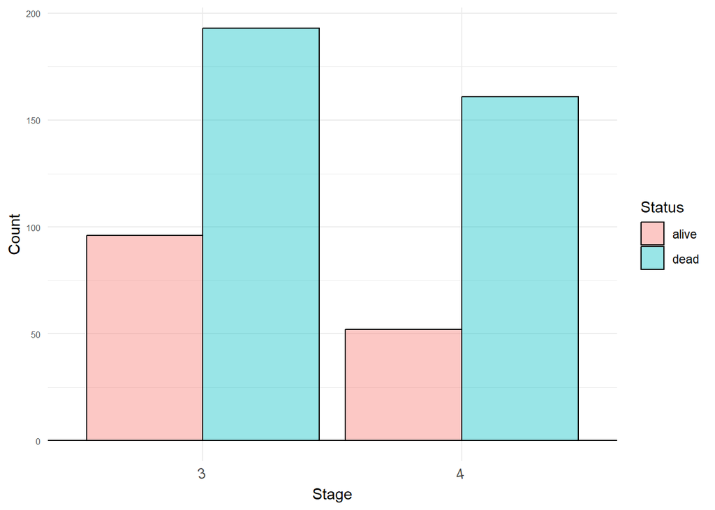

```r
(prostate_tidy |>
  mutate(stage = factor(stage),
         is_alive = factor(is_alive)) |>
  ggplot(aes(
    x = stage,
    fill = is_alive)) +
  geom_bar(
    color = 'black',
    position = "dodge",
    alpha = 0.4) +
  geom_hline(yintercept = 0) +
  theme_minimal() +
  theme(legend.position = "right",
        axis.text.x = element_text(angle = 10, hjust = 1, size = 10, vjust = 1.5),
        axis.text.y = element_text(size = 6)) +
  labs(x = "Stage", y = "Count", fill = "Status")) |>
save_and_show("status_comparison_hist")
```

```r
prostate_tidy |>
  group_by(stage, is_alive) |>
  summarize(n = n())
```

```
# A tibble: 4 × 3
# Groups:   stage [2]
  stage is_alive     n
  <dbl> <chr>    <int>
1     3 alive       96
2     3 dead       193
3     4 alive       52
4     4 dead       161
```

As mentioned the dataset consists of 502 patients, as seen above. 96 of were in stage 3 and alive while 193 of had died. For stage for 4, 52 were alive and 161 patients had died.

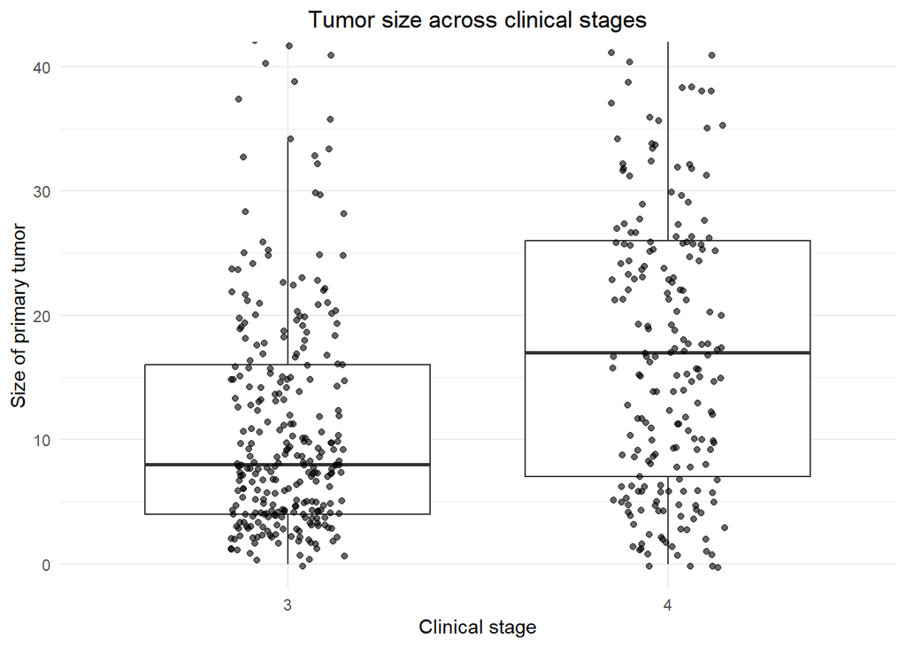

```r
full_df <- prostate_tidy |> mutate(stage = factor(stage, levels = c(3,4)))

full_df |>
  ggplot(aes(x = stage, y = size_of_primary_tumor)) +
  geom_boxplot(outlier.shape = NA) +      # hide the outliners
  geom_jitter(width = 0.15, alpha = 0.6) +
  coord_cartesian(ylim = c(0, 40)) +      # focus on the main part
  labs(
    x = "Clinical stage",
    y = "Size of primary tumor",
    title = "Tumor size across clinical stages"
  ) +
  theme_minimal()+
  theme(plot.title = element_text(hjust = 0.5) # keep titles in the middle
  )
```

A monotonic increase in tumor size across stages suggests that tumor size is a useful measure of disease progression and may influence survival risk.

## Treatment groups

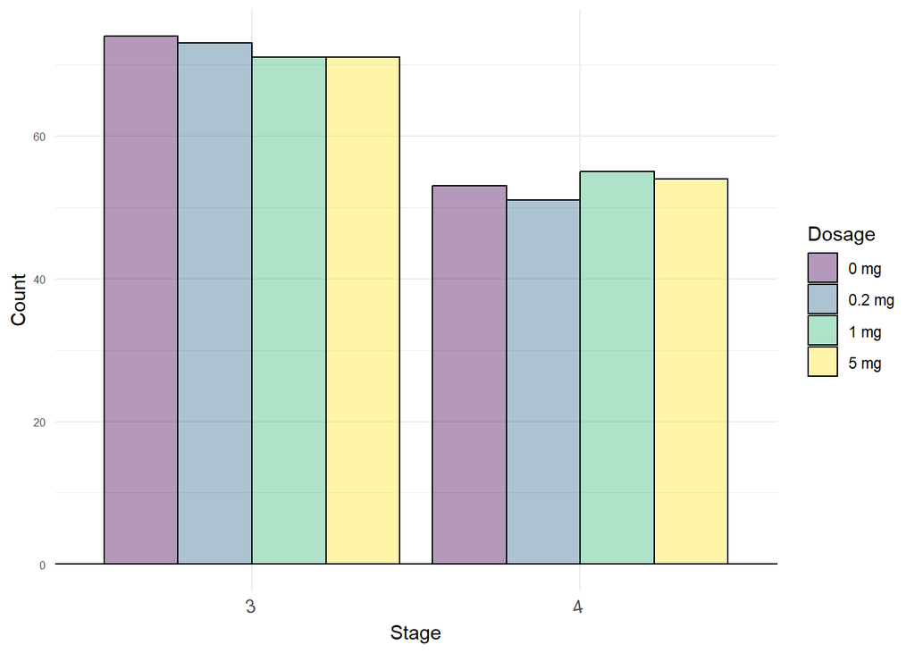

```r
(prostate_tidy |>
  mutate(stage = factor(stage),
         dosage = factor(dosage)) |>
  ggplot(aes(x = stage,
         fill = dosage)) +
  geom_bar(
    color = 'black',
    position = "dodge",
    alpha = 0.4) +
  geom_hline(yintercept = 0) +
  scale_fill_viridis_d(
    option = "D",
    labels = function(x) paste0(x, " mg")
    ) +
  theme_minimal() +
  theme(legend.position = "right",
        axis.text.x = element_text(angle = 10, hjust = 1, size = 10, vjust = 1.5),
        axis.text.y = element_text(size = 6)) +
  labs(x = "Stage", y = "Count", fill = "Dosage")) |>
save_and_show("dosage_dist_by_stage")
```

## Tumor size distribution

We can see there the treatment groups are very evenly distributed.

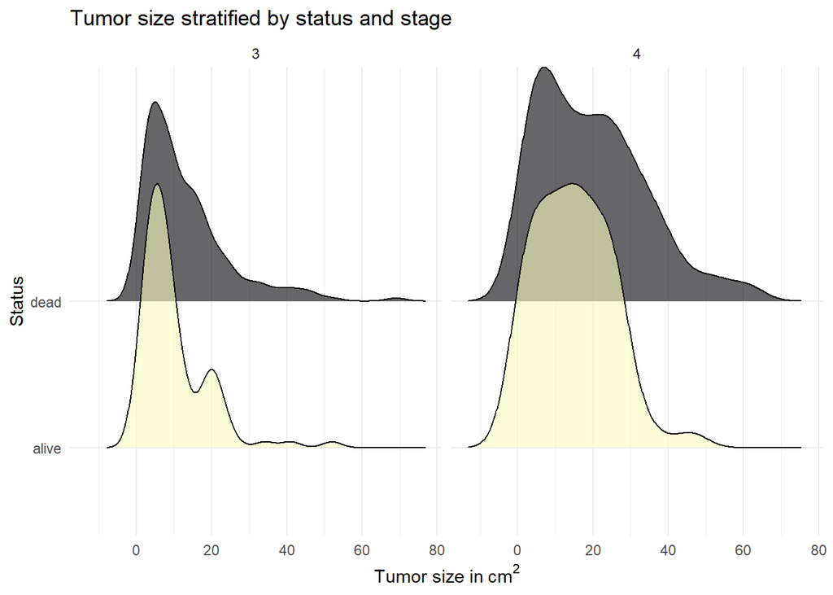

```r
prostate_tidy |>
  mutate(is_alive = factor(is_alive),
         stage = factor(stage)) |>
  ggplot(aes(x = size_of_primary_tumor, y = is_alive, fill = is_alive)) +
  geom_density_ridges(alpha = 0.6, color = "black") +
  facet_wrap(~stage) +
  scale_fill_manual(
    values = c("alive" = "#FCFDBFFF", "dead" = "#000004FF")) +
  labs(title = "Tumor size stratified by status and stage",
       x = bquote('Tumor size in' ~ cm^2), y = "Status") +
  theme_minimal(base_family = "lato") +
  theme(legend.position = "none")
```

## Causes of death

Most importantly we also want to investigate the most prevelant causes of death.

```r
prostate_tidy |>
  mutate(cause_of_death = factor(cause_of_death)) |>
  group_by(cause_of_death) |>
  filter(!is.na(cause_of_death)) |> # for alive
  summarize(n = n())
```

```
# A tibble: 9 × 2
  cause_of_death            n
  <fct>                 <int>
1 cerebrovascular          31
2 heart or vascular        96
3 other ca                 25
4 other specific non-ca    28
5 prostatic ca            130
6 pulmonary embolus        14
7 respiratory disease      16
8 unknown cause             7
9 unspecified non-ca        7
```

As expected the leading cause of death of individuals in the study were prostatic cancer or other types, with heart and vascular also have a prominent representation.

## Density of measurements: AP and Serum hemoglobin

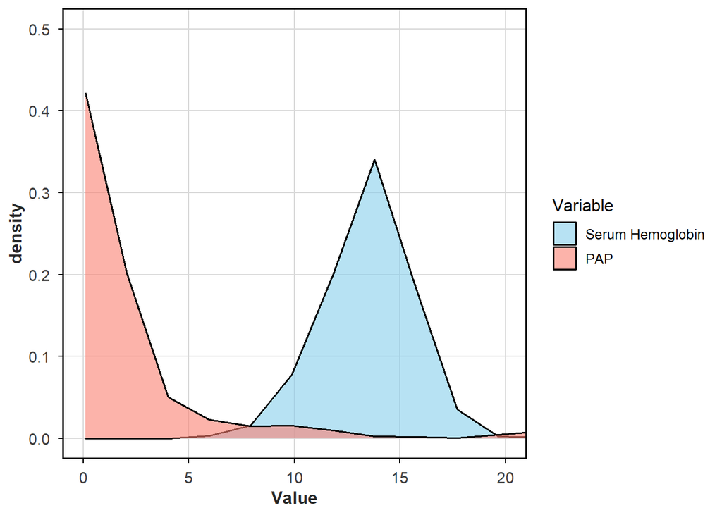

```r
(prostate_tidy |>
  pivot_longer(
    cols = c(serum_prostatic_acid_phosphatase, serum_hemoglobin),
    names_to = "variable",
    values_to = "value") |>
  ggplot(aes(x = value, fill = variable)) +
  geom_density(alpha = 0.6) +
  coord_cartesian(xlim = c(0, 20), ylim = c(0, 0.5)) +
  scale_fill_manual(
    values = c(
      "serum_prostatic_acid_phosphatase" = "salmon",
      "serum_hemoglobin" = "skyblue"),
    labels = c(
      "serum_prostatic_acid_phosphatase" = "PAP",
      "serum_hemoglobin" = "Serum Hemoglobin")) +
  labs(x = "Value", fill = "Variable") +
  best_theme()) |>
save_and_show("distribution_of_sh_and_pap")
```

We see the vast majority of the variables are within the bottom range of respectively 0-5 for AP and 8-20 for Serum hemoglobin. Worth noting is that present in the data set are several outliers who show very high measurements of AP, up to 900+.

# Analysis

```r
library("tidyverse")
library("readr")
library("broom")
source("99_proj_func.R") # custom functions and theme
```

## Load data

We load the data that was augmented for modelling:

```r
load("../data/04_data_for_modelling.Rdata")
```

# Modelling tumor size as a function of variables

Firstly a preliminary analysis of linear model of variables against tumor size as an indicator of disease progression is done.

```r
df_long_nested_model <- df_long_nested |>
  mutate(model_object = map(data,
                            ~lm(size_of_primary_tumor ~ value,
                                data = .x))) |>
  mutate(tidy_model = map(model_object, ~tidy(.x,
                                              conf.int = TRUE,
                                              conf.level = 0.95))) |>
  unnest(cols = tidy_model) |>
  filter(term == "value") |>  #discard intercept terms
  mutate(p_adjusted = p.adjust(p.value)) |> # correct for multiple testing
  arrange(p_adjusted) #sort pvalues to reveal highest significance

df_long_nested_model |>
  select(-data, -model_object, -term, -std.error, -statistic) |>
  print()
```

```
# A tibble: 16 × 6
# Groups:   variable [16]
   variable                      estimate  p.value conf.low conf.high p_adjusted
   <chr>                            <dbl>    <dbl>    <dbl>     <dbl>      <dbl>
 1 combined_index                 2.32    7.08e-18   1.81      2.83     7.08e-18
 2 stage                          6.71    1.67e- 9   4.57      8.86     1.67e- 9
 3 bone_metastases                8.97    2.90e- 9   6.06     11.9      2.90e- 9
 4 serum_prostatic_acid_phospha…  0.116   2.63e- 5   0.0623    0.170    2.63e- 5
 5 follow_up_months              -0.0955  5.96e- 5  -0.142    -0.0492   5.96e- 5
 6 is_alive                       4.43    2.95e- 4   2.04      6.81     2.95e- 4
 7 medical_history               -2.66    1.84e- 2  -4.87     -0.450    1.84e- 2
 8 serum_hemoglobin              -0.663   2.03e- 2  -1.22     -0.103    2.03e- 2
 9 performance                    2.68    4.24e- 2   0.0922    5.28     4.24e- 2
10 dia_blood_pressure            -0.467   2.24e- 1  -1.22      0.286    2.24e- 1
11 weight                        -0.0472  2.63e- 1  -0.130     0.0355   2.63e- 1
12 sys_blood_pressure             0.222   3.37e- 1  -0.231     0.675    3.37e- 1
13 ekg                            0.158   4.20e- 1  -0.226     0.542    4.20e- 1
14 dosage                        -0.137   6.21e- 1  -0.679     0.406    6.21e- 1
15 treatment                     -0.161   9.00e- 1  -2.68      2.35     9.00e- 1
16 age                            0.00851 9.15e- 1  -0.148     0.165    9.15e- 1
```

Based on these models it appears that most variables have an independent correlation with tumor size. This will be illustrated below.

## Volcano plot

A volcano plot shows our estimate slope vs the p-value.

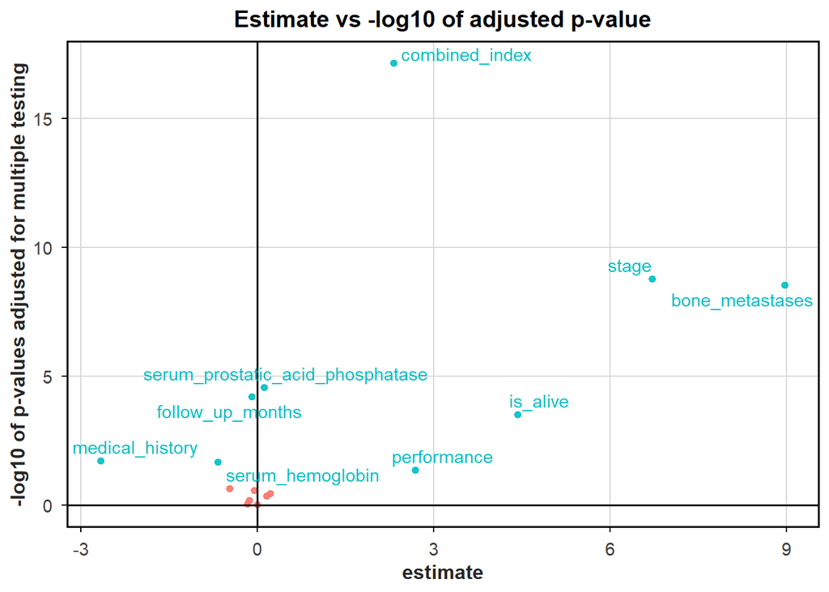

```r
(df_long_nested_model |>
  ggplot(mapping = aes(x = estimate,
                     y = -log10(p_adjusted),
                     color = factor(p_adjusted < 0.05))) +
  geom_point(alpha = 0.9) +
  geom_hline(yintercept = 0)+
  geom_vline(xintercept = 0)+
  best_theme() +
  theme(legend.position = "none") +
  ggrepel::geom_text_repel(aes(label = case_when(p_adjusted < 0.05 ~ variable,
                                                 TRUE ~ ""))) +
  labs(
    title = "Estimate vs -log10 of adjusted p-value",
    y = "-log10 of p-values adjusted for multiple testing",
    x = "estimate")) |>
    save_and_show("linear_volcano")
```

## Forest plot

The forest plot shows the confidence interval of the modeled slope for all variables

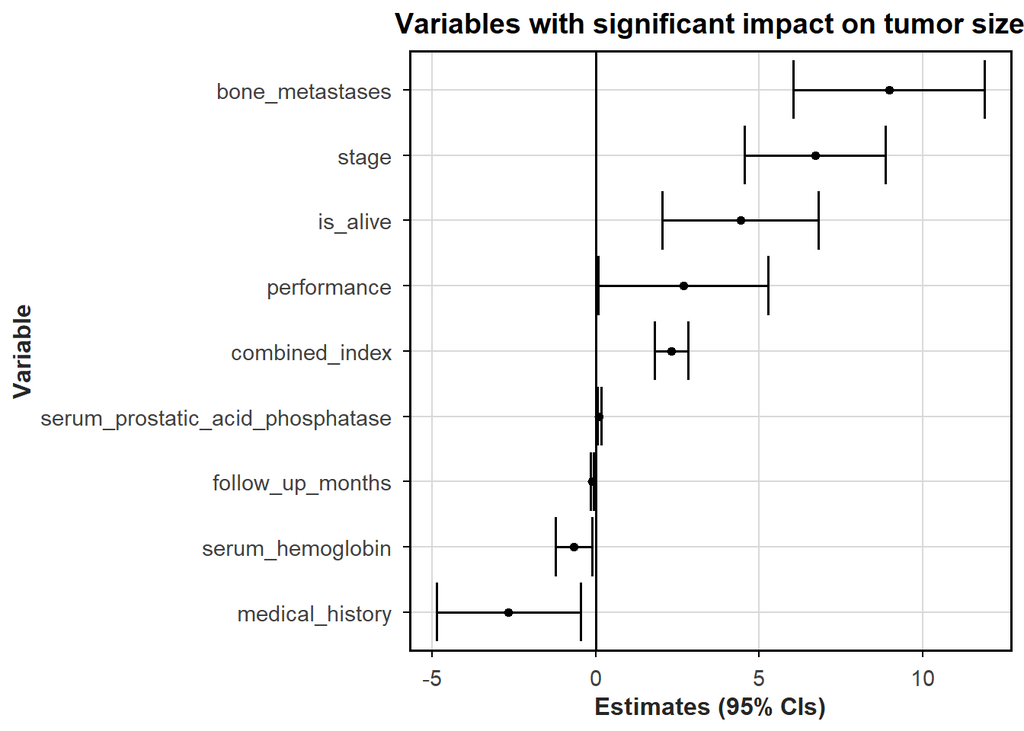

```r
(forest_plot <- df_long_nested_model |>
  filter(p_adjusted < 0.05) |>
  ggplot(mapping = aes(x = estimate,
                       y = fct_reorder(variable, estimate),#sort by the slope
                       xmin = conf.low,
                       xmax = conf.high)) +
  geom_errorbar(orientation = "y") +
  geom_point() +
  geom_vline(xintercept = 0) +
  theme_minimal(base_size = 12) +
  labs(
    x = "Estimates (95% CIs)",
    y = "Variable",
    title = "Variables with significant impact on tumor size"
  ) +
  best_theme()) |>
  save_and_show("linear_forest_plot")
```

## Residual QQ-plots

Here we seek to validate if the linear models make sense of if there is a depature from expected normality.

```r
df_resids <- df_long_nested_model |>
  mutate(aug = map(model_object, broom::augment)) |>
  unnest(aug)
```

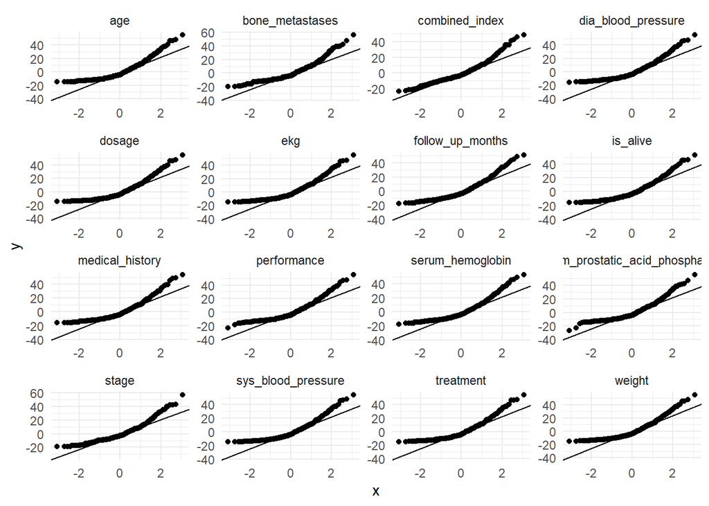

```r
(ggplot(df_resids, aes(sample = .resid)) +
  stat_qq() +
  stat_qq_line() +
  facet_wrap(~ variable, scales = "free") +
  theme_minimal()) |>
  save_and_show("linear_qq")
```

Evident from the QQ-plots are a distinct departure from the normal-distribution in tails. This is present in each model and therefore it is likely that tumor size has outliers. This is investigated following by a histogram and QQ-plot.

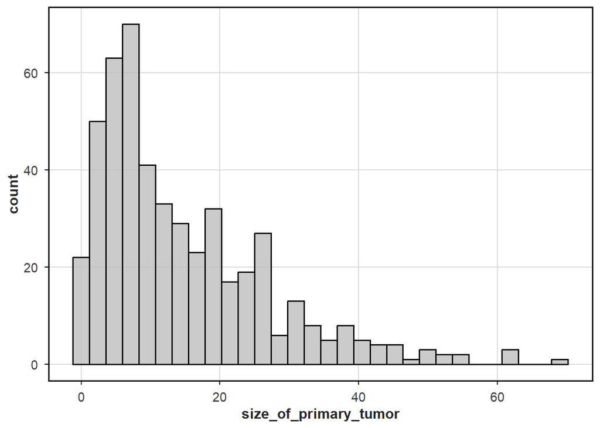

```r
(df_num |>
  ggplot() +
  geom_histogram(aes(x = size_of_primary_tumor),
                 color = "black", alpha = 0.8, fill = "grey") +
  best_theme()) |>
save_and_show("tumor_histogram")
```

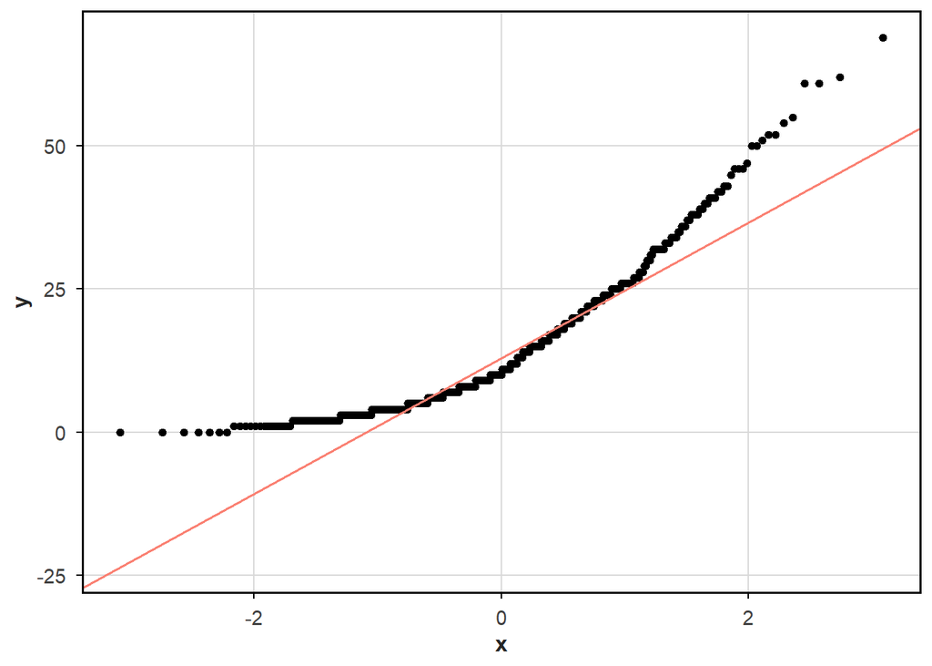

```r
(df_num |>
  ggplot(aes(sample = size_of_primary_tumor)) +
  stat_qq() +
  stat_qq_line(color = "salmon") +
  best_theme()) |>
save_and_show("tumor_qq")
```

These two plots confirm a definite departure from normality, indicative that log-transformed data would make a better fit.

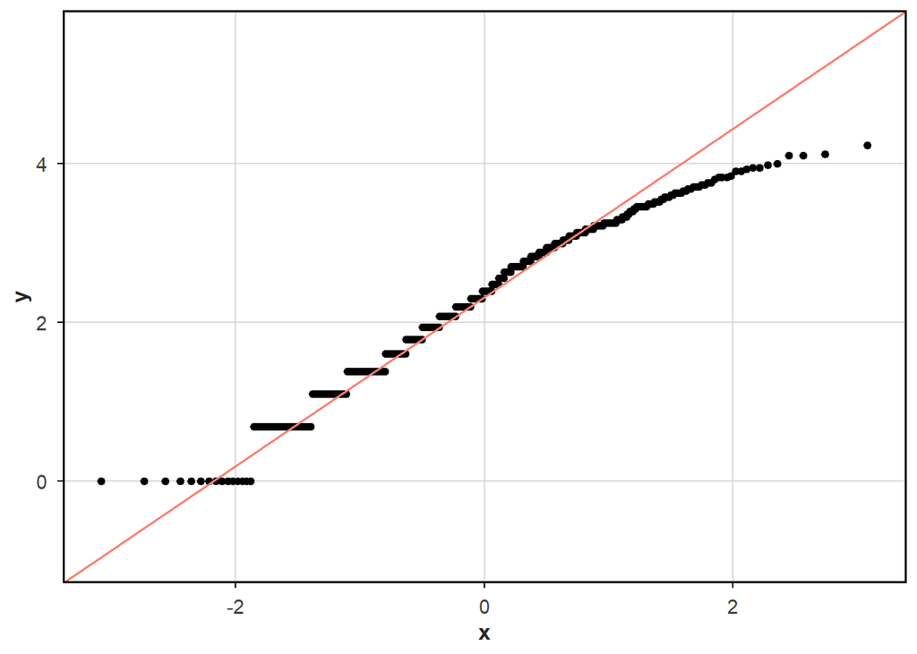

```r
(df_num |>
  filter(size_of_primary_tumor > 0) |>
  ggplot(aes(sample = log(size_of_primary_tumor))) +
  stat_qq() +
  stat_qq_line(color = "salmon") +
  best_theme()) |>
save_and_show("log_tumor_qq")
```

Evident from the model is a much closer normal distribution even if an S-shape is present this is likely due to a few outliers, but overall it reveals a logarithmic scale may suit the data better.

# Modelling based on log transformed data

As just confirmed it is to be investigated wether a log-transformation of our data improves correlations. This requires dropping patients with tumor size zero.

```r
df_long_log <- df_long_nested |>
  unnest(cols = c(data)) |>
  filter(size_of_primary_tumor > 0)

df_long_log |> slice_sample(n = 10)
```

```
# A tibble: 160 × 4
# Groups:   variable [16]
   variable patient_no size_of_primary_tumor value
   <chr>         <dbl>                 <dbl> <dbl>
 1 age             160                    16    72
 2 age              39                    26    53
 3 age             457                     1    77
 4 age             251                     4    78
 5 age             447                     2    74
 6 age             271                    19    79
 7 age             423                     4    72
 8 age             250                    16    79
 9 age               5                    34    67
10 age             428                    30    56
# ℹ 150 more rows
```

*Nesting the model objects for cleanliness.*

```r
df_long_log_nest <- df_long_log |>
  group_by(variable) |>
  nest()
```

## Model of logarithmic tumor size:

```r
df_long_nested_model_log <- df_long_log_nest |>
  mutate(model_object = map(data,
                            ~lm(log(size_of_primary_tumor) ~ value,
                                data = .x))) |>
  mutate(tidy_model = map(model_object, ~tidy(.x,
                                              conf.int = TRUE,
                                              conf.level = 0.95))) |>
  unnest(cols = tidy_model) |>
  filter(term == "value") |>  #discard intercept terms
  mutate(p_adjusted = p.adjust(p.value)) |> # correct for multiple testing
  arrange(p_adjusted) #sort pvalues to reveal highest significance

df_long_nested_model_log |>
  select(-data, -model_object, -term, -std.error, -statistic) |>
  print()
```

```
# A tibble: 16 × 6
# Groups:   variable [16]
   variable                      estimate  p.value conf.low conf.high p_adjusted
   <chr>                            <dbl>    <dbl>    <dbl>     <dbl>      <dbl>
 1 combined_index                 1.58e-1 6.12e-14  0.118     0.198     6.12e-14
 2 stage                          4.69e-1 4.28e- 8  0.303     0.634     4.28e- 8
 3 bone_metastases                6.16e-1 8.95e- 8  0.393     0.839     8.95e- 8
 4 serum_prostatic_acid_phospha…  8.46e-3 5.56e- 5  0.00437   0.0126    5.56e- 5
 5 is_alive                       2.95e-1 1.69e- 3  0.111     0.478     1.69e- 3
 6 follow_up_months              -5.63e-3 2.10e- 3 -0.00921  -0.00205   2.10e- 3
 7 serum_hemoglobin              -5.41e-2 1.34e- 2 -0.0969   -0.0113    1.34e- 2
 8 medical_history               -2.11e-1 1.44e- 2 -0.380    -0.0423    1.44e- 2
 9 sys_blood_pressure             1.93e-2 2.73e- 1 -0.0153    0.0540    2.73e- 1
10 dosage                        -2.27e-2 2.85e- 1 -0.0643    0.0190    2.85e- 1
11 dia_blood_pressure            -2.73e-2 3.50e- 1 -0.0848    0.0301    3.50e- 1
12 ekg                            1.15e-2 4.45e- 1 -0.0180    0.0409    4.45e- 1
13 performance                    7.31e-2 4.68e- 1 -0.125     0.271     4.68e- 1
14 treatment                     -3.26e-2 7.40e- 1 -0.225     0.160     7.40e- 1
15 age                           -1.40e-3 8.18e- 1 -0.0133    0.0105    8.18e- 1
16 weight                         1.01e-4 9.75e- 1 -0.00624   0.00644   9.75e- 1
```

## Preparing for residual plots

```r
df_resids_log <- df_long_nested_model_log |>
  mutate(aug = map(model_object,
                   broom::augment)) |>
  unnest(aug)
```

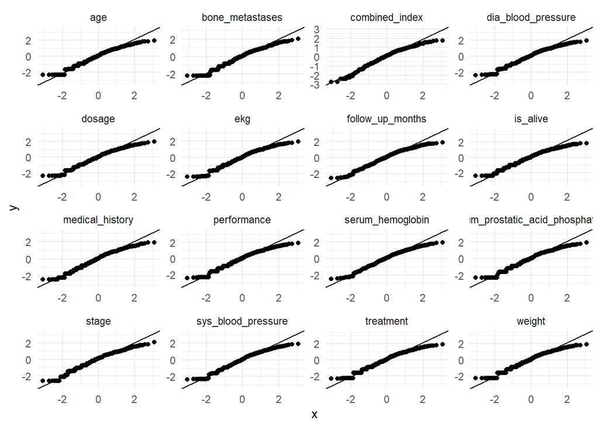

```r
(ggplot(df_resids_log, aes(sample = .resid)) +
  stat_qq() +
  stat_qq_line() +
  facet_wrap(~ variable, scales = "free") +
  theme_minimal()) |>
save_and_show("log_qq")
```

Aligning with our log-transformed tumor data the variables now also show a smaller from expected expectation normality.

## Volcano plot

A volcano plot shows our estimate slope vs the p-value.

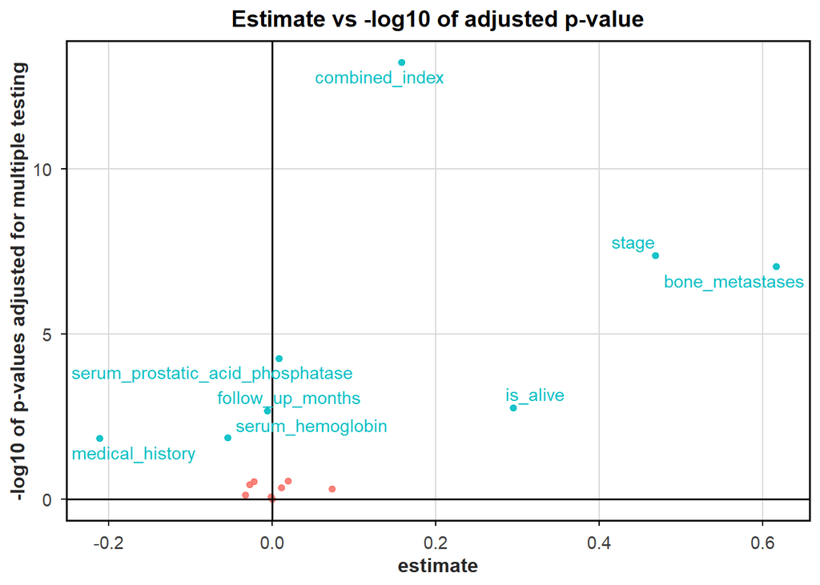

```r
(
df_long_nested_model_log |>
  ggplot(mapping = aes(x = estimate,
                     y = -log10(p_adjusted),
                     color = factor(p_adjusted < 0.05))) +
  geom_point(alpha = 0.9) +
  geom_hline(yintercept = 0)+
  geom_vline(xintercept = 0)+
  best_theme() +
  theme(legend.position = "none") +
  ggrepel::geom_text_repel(aes(label = case_when(p_adjusted < 0.05 ~ variable,
                                                 TRUE ~ ""))) +
  labs(
    title = "Estimate vs -log10 of adjusted p-value",
    y = "-log10 of p-values adjusted for multiple testing",
    x = "estimate")) |>
save_and_show(plot_name = "log_volcano")
```

## Forest plot

The forest plot shows the confidence interval of the modelled slope for all variables

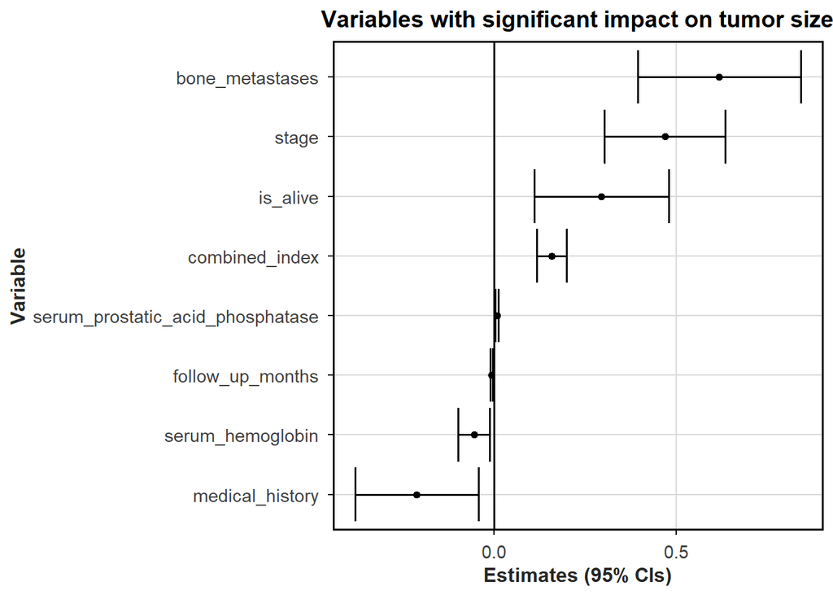

```r
(df_long_nested_model_log |>
  filter(p_adjusted < 0.05) |>
  ggplot(mapping = aes(x = estimate,
                       y = fct_reorder(variable, estimate),#sort byr the skope
                       xmin = conf.low,
                       xmax = conf.high)) +
  geom_errorbar(orientation = "y") +
  geom_point() +
  geom_vline(xintercept = 0) +
  theme_minimal(base_size = 12) +
  labs(
    x = "Estimates (95% CIs)",
    y = "Variable",
    title = "Variables with significant impact on tumor size"
  ) +
  best_theme()) |>
save_and_show("log_forest")
```

# Correlation among continuous clinical variables

Beyond comparison with tumor size a pairwise correlation for the quantitative biological and physiological measurements is computed to identify potential collinearity before survival analysis.

```r
# Select relevant numeric variables
corr_df <- df_num |>
  select(
    age,
    weight,
    serum_hemoglobin,
    serum_prostatic_acid_phosphatase,
    size_of_primary_tumor)

# Compute raw correlation matrix
corr_mat <- cor(corr_df, use = "pairwise.complete.obs")
```

### Correlation heatmap

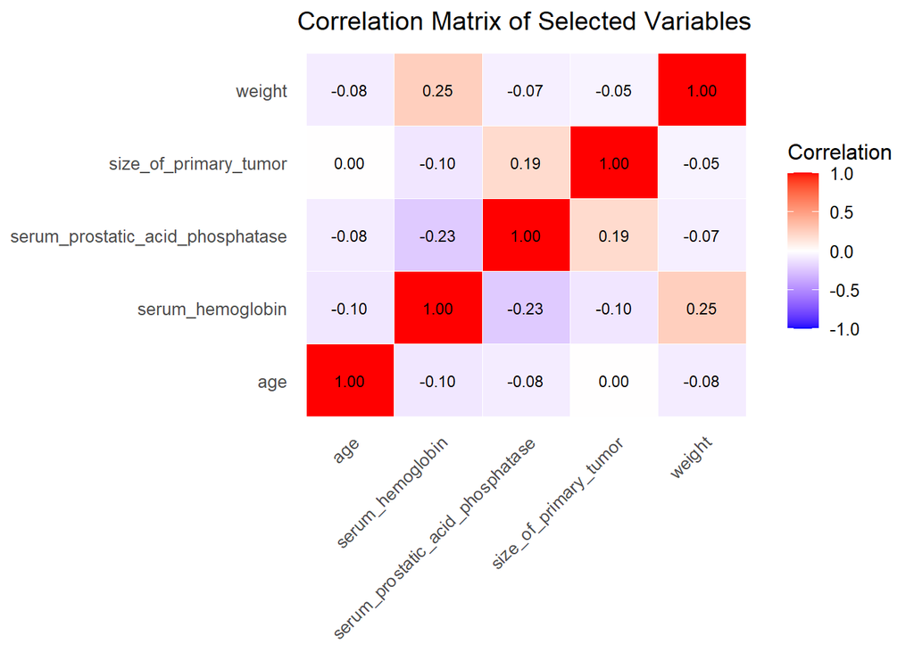

```r
# Convert matrix to long format for ggplot2
corr_long <- as.data.frame(corr_mat) |>
  rownames_to_column("Var1") |>
  pivot_longer(
    cols = -Var1,
    names_to = "Var2",
    values_to = "cor"
  )

corr_long |>
  ggplot(aes(x = Var2, y = Var1, fill = cor)) +
  geom_tile(color = "white") +
  geom_text(aes(label = sprintf("%.2f", cor)), size = 3) +
  scale_fill_gradient2(
    low = "blue",
    mid = "white",
    high = "red",
    midpoint = 0,
    limits = c(-1, 1),
    name = "Correlation"
  ) +
  theme_minimal(base_size = 12) +
  theme(
    axis.text.x = element_text(angle = 45, hjust = 1), # retate words
    panel.grid = element_blank() # remove grid lines
  ) +
  labs(
    title = "Correlation Matrix of Selected Variables",
    x = NULL,
    y = NULL
  )
```

# Exploratory multivariate analysis

Expanding on colliniarity and variables that have been shown significant in relation to log(`size_of_primary_tumor`) a few multivariate models are explored.

```r
model_tidy <- lm(log(size_of_primary_tumor) ~
                   serum_hemoglobin +
                   medical_history +
                   bone_metastases +
                   serum_prostatic_acid_phosphatase,
                 data = df_num |>
                   filter(size_of_primary_tumor > 0)) |>
  tidy()
print(model_tidy)
```

```
# A tibble: 5 × 5
  term                             estimate std.error statistic  p.value
  <chr>                               <dbl>     <dbl>     <dbl>    <dbl>
1 (Intercept)                       2.57      0.310       8.30  1.09e-15
2 serum_hemoglobin                 -0.0206    0.0221     -0.930 3.53e- 1
3 medical_history                  -0.187     0.0837     -2.24  2.57e- 2
4 bone_metastases                   0.463     0.126       3.68  2.62e- 4
5 serum_prostatic_acid_phosphatase  0.00473   0.00225     2.10  3.61e- 2
```

## Logistic regression predicting survivability (bad results)

A binary logistic regression is perfomed on the `is_alive` column. This is of limited biological relevanc but may reveal an interesting insight. interesting cols: select(is_alive, age, weight, size_of_primary_tumor,serum_prostatic_acid_phosphatase, performance)

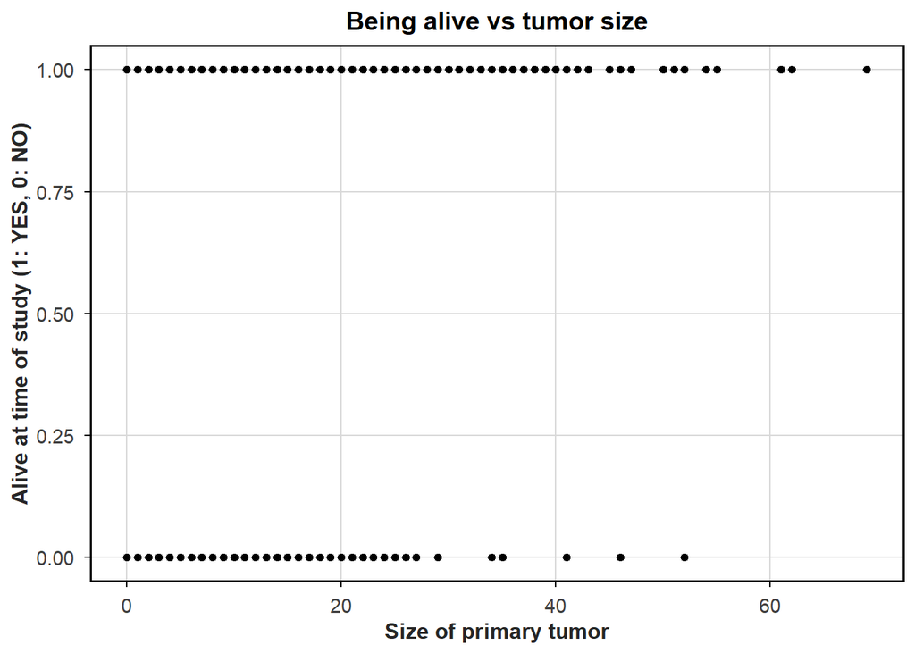

```r
# Turn df is_alive column into numeric variable for modelling:
df_a_ts <- df_num |>
  select(is_alive, size_of_primary_tumor) |>
  drop_na()


df_a_ts |>
  ggplot(aes(y = is_alive,
             x = size_of_primary_tumor)) +
  geom_point() +
  labs(
    x = "Size of primary tumor",
    y = "Alive at time of study (1: YES, 0: NO)",
    title = "Being alive vs tumor size"
  ) +
  best_theme()
```

There seems to be a threshold for tumor size vs being alive at the time of study.

### Fitting the logistic regression

```r
my_glm_mdl <- glm(formula = is_alive ~ size_of_primary_tumor,
                  family = binomial(link = "logit"),
                  data = df_num)
my_glm_mdl
```

```
Call:  glm(formula = is_alive ~ size_of_primary_tumor, family = binomial(link = "logit"),
    data = df_num)

Coefficients:
          (Intercept)  size_of_primary_tumor
               0.4333                 0.0339

Degrees of Freedom: 490 Total (i.e. Null);  489 Residual
  (5 observations deleted due to missingness)
Null Deviance:      592.4
Residual Deviance: 578.1    AIC: 582.1
```

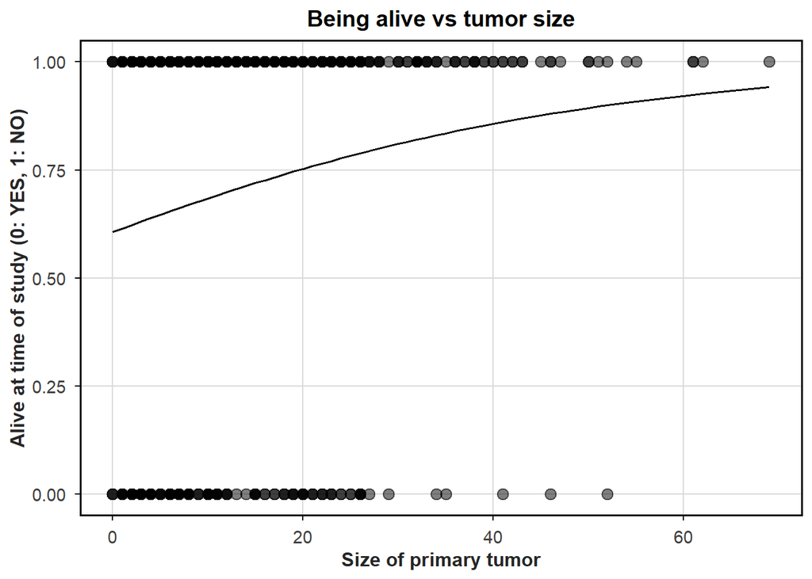

```r
df_a_ts |>
  mutate(my_glm_model = pluck(my_glm_mdl, "fitted.values")) |>
  ggplot(aes(x = size_of_primary_tumor, y = is_alive)) +
  geom_point(alpha = 0.5,
             size = 3) +
  geom_line(aes(y = my_glm_model)) +
  labs(
    x = "Size of primary tumor",
    y = "Alive at time of study (0: YES, 1: NO)",
    title = "Being alive vs tumor size"
  ) +
  best_theme()
```

As mentioned there seems to be a certain correlation between these two but it is not a very telling analysis so it should not be considered.

## Multivariate on measurements – No significant conclusions

Mentioned preivously this is an exploration of blood and treatment data to evaluate whether it could have an explanatory effect. This is conducted due to QQ-plots showing some variation and S-tailing. First explored is the tumor size, and potential effects of treatment, AP and hemoglobin.

```r
ap_ts_log_tidy_model <- lm(
  log(size_of_primary_tumor) ~
    log(serum_prostatic_acid_phosphatase) +
    serum_prostatic_acid_phosphatase +
    serum_hemoglobin +
    dosage +
    bone_metastases +
    stage,
  data = df_num |>
    filter(size_of_primary_tumor > 0))

print(ap_ts_log_tidy_model |>
        tidy())
```

```
# A tibble: 7 × 5
  term                                  estimate std.error statistic     p.value
  <chr>                                    <dbl>     <dbl>     <dbl>       <dbl>
1 (Intercept)                            3.06      0.555       5.50      6.05e-8
2 log(serum_prostatic_acid_phosphatase)  0.242     0.0543      4.46      1.01e-5
3 serum_prostatic_acid_phosphatase      -0.00546   0.00298    -1.83      6.76e-2
4 serum_hemoglobin                      -0.0268    0.0217     -1.24      2.17e-1
5 dosage                                -0.0297    0.0200     -1.48      1.39e-1
6 bone_metastases                        0.261     0.136       1.92      5.51e-2
7 stage                                 -0.118     0.132      -0.892     3.73e-1
```

Disregarding non-significant values:

```r
ap_ts_log_tidy_model |>
  tidy() |>
  mutate(padj = p.adjust(p.value, method = "fdr")) |>
  filter(padj < 0.05) |>
  save_and_show_table("log_tumor_sig_fit")
```

```
# A tibble: 2 × 6
  term                              estimate std.error statistic p.value    padj
  <chr>                                <dbl>     <dbl>     <dbl>   <dbl>   <dbl>
1 (Intercept)                          3.06     0.555       5.50 6.05e-8 4.23e-7
2 log(serum_prostatic_acid_phospha…    0.242    0.0543      4.46 1.01e-5 3.55e-5
```

Seems that log(AP) does have a significant correlation with tumor size but not more than the log tumor size.

## Exploratory analysis of effects on prostatic acid phosphatase

```r
ap_es_log_tidy_model <- lm(
  serum_prostatic_acid_phosphatase ~
    dosage +
    I(dosage^2) +
    I(dosage^2)*serum_hemoglobin +
    bone_metastases*dosage +
    log(size_of_primary_tumor),
  data = df_num |> filter(size_of_primary_tumor > 0))

print(ap_es_log_tidy_model |> tidy())
```

```
# A tibble: 8 × 5
  term                         estimate std.error statistic       p.value
  <chr>                           <dbl>     <dbl>     <dbl>         <dbl>
1 (Intercept)                    9.16      7.55      1.21   0.226
2 dosage                         0.259     2.77      0.0933 0.926
3 I(dosage^2)                    1.30      0.802     1.62   0.106
4 serum_hemoglobin              -0.794     0.516    -1.54   0.124
5 bone_metastases               19.6       3.18      6.16   0.00000000156
6 log(size_of_primary_tumor)     2.00      0.918     2.17   0.0302
7 I(dosage^2):serum_hemoglobin  -0.0951    0.0430   -2.21   0.0274
8 dosage:bone_metastases        -0.341     1.15     -0.298  0.766
```

Again filtering for non-significant contributors.

```r
ap_es_log_tidy_model |>
  tidy() |>
  mutate(padj = p.adjust(p.value, method = "fdr")) |>
  filter(padj < 0.05) |>
  print()
```

```
# A tibble: 1 × 6
  term            estimate std.error statistic       p.value         padj
  <chr>              <dbl>     <dbl>     <dbl>         <dbl>        <dbl>
1 bone_metastases     19.6      3.18      6.16 0.00000000156 0.0000000125
```

We see the primary contributors to the AP levels to be bone metastasis, a relevant conclusion as this is prevalent in advanced diagnosis.

## Exploratory analysis of effects on bone metastasis

We wanted to investigate the correlation between bone metastatis and blood factors.

```r
bm_ap_hb_model <- lm(
  bone_metastases ~
    serum_prostatic_acid_phosphatase*I(dosage**2) +
    serum_prostatic_acid_phosphatase*serum_hemoglobin +
    dosage*serum_hemoglobin,
  data = df_num)

print(bm_ap_hb_model |> tidy())
```

```
# A tibble: 8 × 5
  term                                      estimate std.error statistic p.value
  <chr>                                        <dbl>     <dbl>     <dbl>   <dbl>
1 (Intercept)                                6.78e-1 0.129         5.25  2.23e-7
2 serum_prostatic_acid_phosphatase          -1.22e-2 0.00363      -3.35  8.75e-4
3 I(dosage^2)                               -1.87e-2 0.00902      -2.08  3.83e-2
4 serum_hemoglobin                          -4.68e-2 0.00950      -4.92  1.18e-6
5 dosage                                     9.47e-2 0.0695        1.36  1.74e-1
6 serum_prostatic_acid_phosphatase:I(dosag… -2.66e-5 0.0000654    -0.407 6.84e-1
7 serum_prostatic_acid_phosphatase:serum_h…  1.81e-3 0.000336      5.38  1.14e-7
8 serum_hemoglobin:dosage                    9.84e-4 0.00391       0.252 8.01e-1
```

```r
bm_ap_hb_model |>
  tidy() |>
  mutate(padj = p.adjust(p.value, method = "fdr")) |>
  filter(padj < 0.05) |>
  save_and_show_table("bone_sig_fit")
```

```
# A tibble: 4 × 6
  term                              estimate std.error statistic p.value    padj
  <chr>                                <dbl>     <dbl>     <dbl>   <dbl>   <dbl>
1 (Intercept)                        0.678    0.129         5.25 2.23e-7 8.90e-7
2 serum_prostatic_acid_phosphatase  -0.0122   0.00363      -3.35 8.75e-4 1.75e-3
3 serum_hemoglobin                  -0.0468   0.00950      -4.92 1.18e-6 3.14e-6
4 serum_prostatic_acid_phosphatase…  0.00181  0.000336      5.38 1.14e-7 8.90e-7
```

Here we can confirm that bone metastasis is indeed influenced by both AP and hemoglobin levels but not estrogen treatment dosage.

# AP levels by bone metastasis status

As just shown serum AP is commonly elevated in advanced prostate cancer and is often used as a surrogate marker for metastatic activity. We compare AP levels between patients with and without bone metastasis and draw a boxplot to show the result.

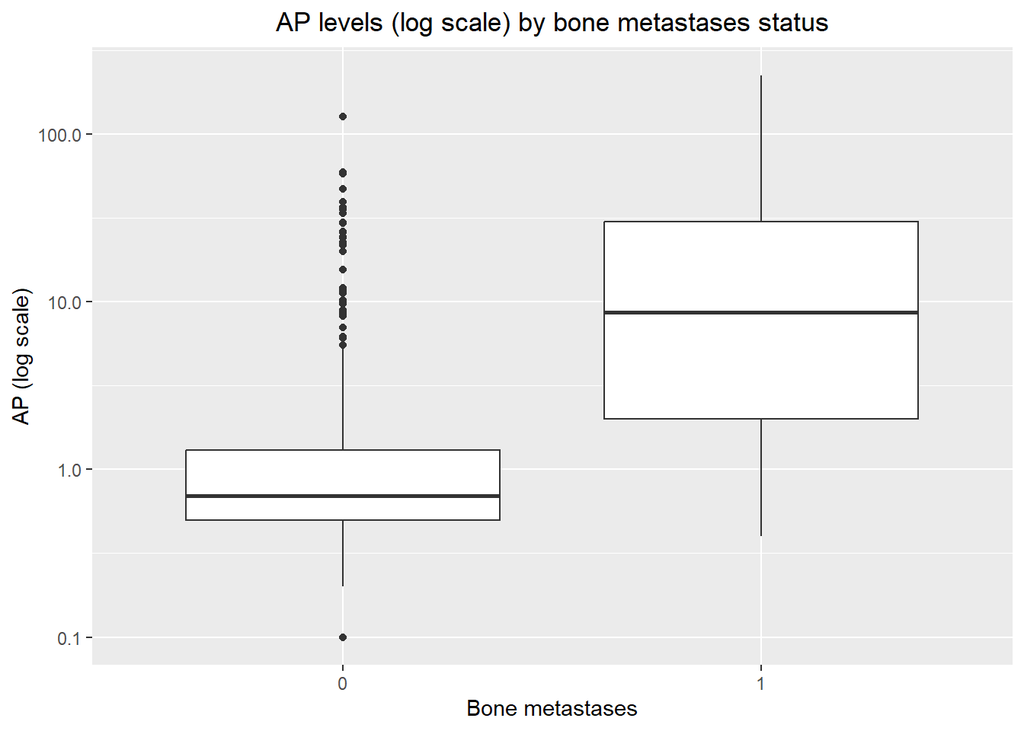

```r
df_num |>
  ggplot(aes(
    x = factor(bone_metastases),
    y = serum_prostatic_acid_phosphatase)) +
  geom_boxplot() +
  scale_y_log10() + # for log scale
  labs(
    x = "Bone metastases",
    y = "AP (log scale)",
    title = "AP levels (log scale) by bone metastases status"
  )+
  theme(plot.title = element_text(hjust = 0.5) # keep titles in the middle
  )
```

We can see that AP levels are expected to be substantially higher in patients with bone metastases, reinforcing AP as a marker of advanced disease. This observation is consistent with the extreme AP values identified earlier in 04_describe.

# Interpretation

# Survial Analysis

```r
library("tidyverse")
library("survival")
library("broom")
source("99_proj_func.R")
```

## Load dataset

In the previous steps, the original prostate dataset was downloaded and cleaned, seraval other necessary variables were added, and the resulting dataset was saved as 03_dat_aug.tsv.gz. The analysis of that dataset will proceed in this section.

```r
full_df <- read_tsv("../data/03_dat_aug.tsv.gz")

# check the data we loaded
full_df |> slice_sample(n = 10)
```

```
# A tibble: 10 × 22
   patient_no stage is_alive cause_of_death        age weight performance
        <dbl> <dbl>    <dbl> <chr>               <dbl>  <dbl> <chr>
 1        208     3        0 <NA>                   59     90 normal activity
 2         48     3        1 unknown cause          59    116 in bed < 50% dayt…
 3        477     4        1 prostatic ca           59     87 normal activity
 4        170     4        1 heart or vascular      73    105 normal activity
 5        414     3        1 other ca               74     91 normal activity
 6        132     3        1 prostatic ca           74     98 normal activity
 7        189     3        0 <NA>                   73     96 normal activity
 8        220     4        1 heart or vascular      71    110 normal activity
 9        186     3        0 <NA>                   67    109 normal activity
10        146     4        1 respiratory disease    75    124 normal activity
# ℹ 15 more variables: medical_history <lgl>, study_date <date>,
#   follow_up_months <dbl>, sys_blood_pressure <dbl>, dia_blood_pressure <dbl>,
#   ekg <chr>, serum_hemoglobin <dbl>, size_of_primary_tumor <dbl>,
#   combined_index <dbl>, serum_prostatic_acid_phosphatase <dbl>,
#   bone_metastases <lgl>, treatment <chr>, dosage <dbl>, MAP <dbl>,
#   treatment_detail <chr>
```

# Baseline comparison between treatment groups

Before conducting survival analyses, it is essential to evaluate whether the treatment groups differ at baseline. The original treatment variable contains four treatment arms (“0.2 mg estrogen”, “1.0 mg estrogen”, “5.0 mg estrogen”, “placebo”). For comparisons, we create a combined variable representing any treatment details then print the table.

```r
full_df <- full_df |>
  mutate(
    treatment_detail = factor(treatment_detail,
                              levels = c("Placebo",
                                         "0.2mg Estrogen",
                                         "1.0mg Estrogen",
                                         "5.0mg Estrogen"))
  )

full_df |>
  select(treatment_detail) |>
  table()
```

```
treatment_detail
       Placebo 0.2mg Estrogen 1.0mg Estrogen 5.0mg Estrogen
           127            122            124            123
```

## Summary statistics by treatment group

Here we take a closer look at variables distribution within treatment groups.

```r
full_df |>
  group_by(treatment_detail) |>
  summarise(
    n = n(),
    age_mean = mean(age, na.rm = TRUE),
    weight_mean = mean(weight, na.rm = TRUE),
    hemoglobin_mean = mean(serum_hemoglobin, na.rm = TRUE),
    ap_mean = mean(serum_prostatic_acid_phosphatase, na.rm = TRUE),
    tumor_size_mean = mean(size_of_primary_tumor, na.rm = TRUE),
    bm_rate = mean(bone_metastases, na.rm = TRUE),
    medical_history_rate = mean(medical_history, na.rm = TRUE)
    )
```

```
# A tibble: 4 × 9
  treatment_detail     n age_mean weight_mean hemoglobin_mean ap_mean
  <fct>            <int>    <dbl>       <dbl>           <dbl>   <dbl>
1 Placebo            127     71.7       100.             13.3    6.36
2 0.2mg Estrogen     122     70.9        99.5            13.4    4.43
3 1.0mg Estrogen     124     71.3        98.2            13.6    7.55
4 5.0mg Estrogen     123     71.9        98.3            13.6    7.46
# ℹ 3 more variables: tumor_size_mean <dbl>, bm_rate <dbl>,
#   medical_history_rate <dbl>
```

As we can see there are a few differences within each treatment group to be analysed.

## Hypothesis tests for group differences

To ensure that patients in different treatment groups have similar health condition a statistic was conducted. Continuous variables were compared using ANOVA, and categorical variables using chi-square tests(these functions are from base R).

```r
# Age
full_df |>
  oneway.test(age ~ treatment_detail,
              data = _)
```

```
    One-way analysis of means (not assuming equal variances)

data:  age and treatment_detail
F = 0.58027, num df = 3.00, denom df = 271.75, p-value = 0.6284
```

```r
# Bone metastasis
chisq.test(table(full_df$bone_metastases, full_df$treatment_detail))
```

```
    Pearson's Chi-squared test

data:  table(full_df$bone_metastases, full_df$treatment_detail)
X-squared = 6.359, df = 3, p-value = 0.09539
```

```r
# Serum AP
full_df |>
  oneway.test(serum_prostatic_acid_phosphatase ~ treatment_detail,
              data = _)
```

```
    One-way analysis of means (not assuming equal variances)

data:  serum_prostatic_acid_phosphatase and treatment_detail
F = 1.1677, num df = 3.00, denom df = 254.72, p-value = 0.3226
```

```r
# Hemoglobin
full_df |>
  oneway.test(serum_hemoglobin ~ treatment_detail,
              data = _)
```

```
    One-way analysis of means (not assuming equal variances)

data:  serum_hemoglobin and treatment_detail
F = 0.67823, num df = 3.00, denom df = 272.82, p-value = 0.566
```

## Interpretation

Baseline comparisons help establish whether survival differences are attributed to treatment itself or reflect initial imbalances. For example, higher serum AP or greater frequency of bone metastasis in one group would imply greater disease severity at baseline, which may independently explain poorer outcomes. The results above provide our data is suitable for the survival analyses presented in the following section.

# Survival analysis

To evaluate whether treatment has an effect on time-to-event outcomes, we perform non-parametric survival analysis using Kaplan–Meier estimators and log-rank tests. The dataset provides follow-up time (`follow_up_months`) and a binary mortality indicator (`event`), which allows construction of survival objects. (*Some of the analysis(like cox models) was done by the package survive, in those sections we’ll pay more attention to data visualization.)*

## Kaplan–Meier survival curves by treatment group

We begin by constructing a survival object:

```r
surv_obj <- Surv(time = full_df$follow_up_months,
                 event = full_df$is_alive)
```

Next, we estimate the Kaplan–Meier curves for the four treatment groups: 0.2 mg estrogen vs 1.0mg estrogen vs 5.0mg estrogen vs placebo. We wrote function km_fit to calculated the survival possibility at each time point and then draw a step plot to the relationship of survival possibility and time.

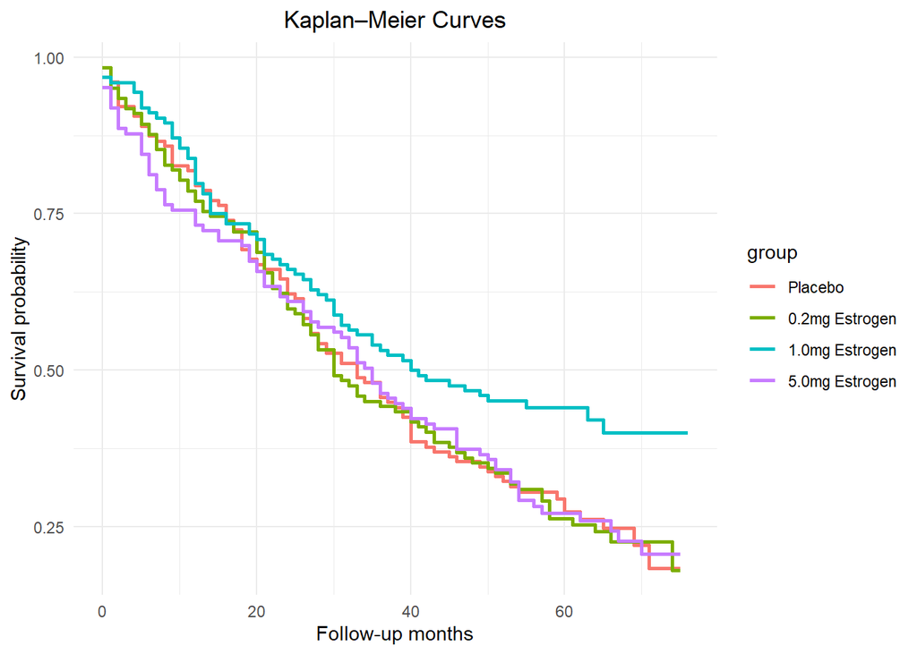

```r
# calculate KM
km_res <- km_fit(
  data = full_df,
  time = "follow_up_months",
  event = "is_alive",
  group = "treatment_detail"
)

# draw survival curve
(km_res |>
  ggplot(aes(x = time, y = surv, color = group)) +
  geom_step(linewidth = 1) +
  labs(
    x = "Follow-up months",
    y = "Survival probability",
    title = "Kaplan–Meier Curves"
  ) +
  theme_minimal() +
  theme(plot.title = element_text(hjust = 0.5) # keep titles in the middle
  )) |> save_and_show("surv_curv by treatment")
```

## Log-rank test

```r
logrank_test <- survdiff(surv_obj ~ treatment_detail, data = full_df)
logrank_test
```

```
Call:
survdiff(formula = surv_obj ~ treatment_detail, data = full_df)

                                  N Observed Expected (O-E)^2/E (O-E)^2/V
treatment_detail=Placebo        127       95     88.1     0.538     0.734
treatment_detail=0.2mg Estrogen 122       93     84.5     0.849     1.141
treatment_detail=1.0mg Estrogen 124       71     93.9     5.603     7.808
treatment_detail=5.0mg Estrogen 123       92     84.4     0.681     0.915

 Chisq= 7.8  on 3 degrees of freedom, p= 0.05
```

# Cox proportional hazards modeling

Kaplan–Meier curves provide an unadjusted comparison of survival between the treatment groups, but they do not account for baseline imbalances in disease severity or physiological status. To estimate treatment effects while controlling for potential confounders, a Cox proportional hazards model is applied. Both univariate and multivariable Cox regressions are considered to evaluate the association between clinical variables and mortality risk.

## Univariate Cox models

First fitted are univariate Cox models for key predictors identified in Sections 2 and 3, including tumor burden (AP, tumor size, bone metastases), physiological status (hemoglobin, age, MAP), and clinical stage.

```
`height` was translated to `width`.
`height` was translated to `width`.
```

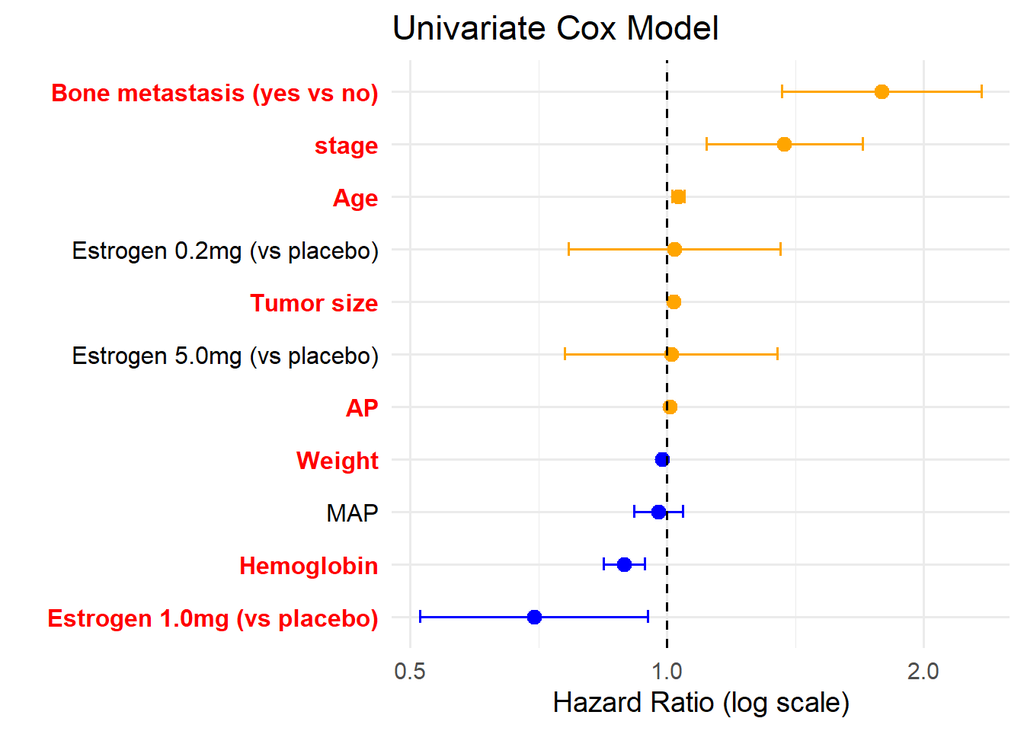

```r
cox_vars <- c("treatment_detail",
              "age",
              "serum_hemoglobin",
              "serum_prostatic_acid_phosphatase",
              "size_of_primary_tumor",
              "bone_metastases",
              "stage",
              "MAP",
              "weight")

# merge the results
uni_df <- map_df(cox_vars, function(v) {
  formula <- as.formula(str_c("Surv(follow_up_months, is_alive) ~ ", v))
  model <- coxph(formula, data = full_df)
  tidy(model, exponentiate = TRUE, conf.int = TRUE) |>
    mutate(variable = v)
})

# rename for cleanner look
uni_df <- uni_df |>
  mutate(
    Variable = case_when(
      variable == "treatment_detail" & grepl("0\\.2mg", term) ~ "Estrogen 0.2mg (vs placebo)",
      variable == "treatment_detail" & grepl("1\\.0mg", term) ~ "Estrogen 1.0mg (vs placebo)",
      variable == "treatment_detail" & grepl("5\\.0mg", term) ~ "Estrogen 5.0mg (vs placebo)",
      variable == "stage" & term == "stage4" ~ "Stage IV (vs Stage III)",
      variable == "bone_metastases" ~ "Bone metastasis (yes vs no)",
      variable == "serum_hemoglobin" ~ "Hemoglobin",
      variable == "size_of_primary_tumor" ~ "Tumor size",
      variable == "serum_prostatic_acid_phosphatase" ~ "AP",
      variable == "MAP" ~ "MAP",
      variable == "age" ~ "Age",
      variable == "weight" ~ "Weight",
      TRUE ~ term
    ),
    HR = estimate,
    lower = conf.low,
    upper = conf.high,
    p_sig = p.value < 0.05,
    HR_color = ifelse(HR > 1, "orange", "blue"),
    label_color = ifelse(p_sig, "red", "black"),
    label_face = ifelse(p_sig, "bold", "plain")
  ) |>
  arrange(HR) |>
  mutate(Variable = factor(Variable, levels = Variable))

# draw forestplot
(uni_df |>
  ggplot(aes(x = HR, y = Variable)) +
  geom_point(aes(color = HR_color), size = 3) +
  geom_errorbarh(aes(xmin = lower, xmax = upper, color = HR_color), height = 0.25) +
  geom_vline(xintercept = 1, linetype = "dashed") +
  scale_color_identity() +
  scale_x_log10() +
  labs(
    title = "Univariate Cox Model",
    x = "Hazard Ratio (log scale)",
    y = ""
  ) +
  theme_minimal(base_size = 14) +
  theme(
    axis.text.y = element_text(size = 12,
                               color = uni_df$label_color,
                               face = uni_df$label_face)
  )) |> save_and_show("Univariate_cox_model")
```

In the forest plot, variables are marked with HR > 1 orange and those with HR < 1 blue. The variables with significant difference are shown red and emphasis their names. The univariate Cox analyses shows that Age, AP, tumor size, bone metastasis, and clinical stage were all associated with increased hazard of death, consistent with known clinical behavior of advanced prostate cancer. Hemoglobin was protective. Among treatment arms, only 1.0mg estrogen showed a significantly reduced hazard compared with placebo. MAP showed no significant association with survival.

## Multivariable Cox model

Next a multivariable model incorporating treatment group and major clinical covariates is fitted. Predictors were chosen based on biological relevance and the exploratory findings from earlier analysis sections.

```
`height` was translated to `width`.
`height` was translated to `width`.
```

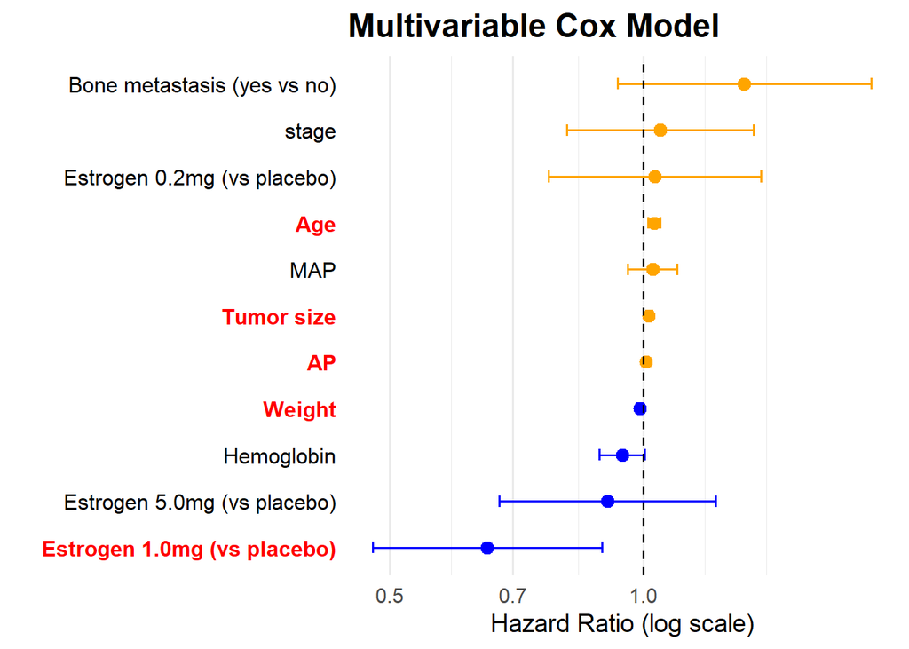

```r
cox_multi <- coxph(
  Surv(follow_up_months, is_alive) ~
    treatment_detail +
    age +
    serum_hemoglobin +
    serum_prostatic_acid_phosphatase +
    size_of_primary_tumor +
    bone_metastases +
    stage +
    MAP+
    weight,
  data = full_df
  )

# clean the result
multi_df <- tidy(cox_multi, exponentiate = TRUE, conf.int = TRUE) |>
  mutate(
    HR = estimate,
    lower = conf.low,
    upper = conf.high,
    Variable = term,
    p_sig = p.value < 0.05,    # whether it's significant
    HR_color = ifelse(HR > 1, "orange", "blue"),
    label_color = ifelse(p_sig, "red", "black"),
    label_face = ifelse(p_sig, "bold", "plain")
  ) |>
  # rename
  mutate(
    Variable = case_when(
      grepl("0\\.2mg", Variable) ~ "Estrogen 0.2mg (vs placebo)",
      grepl("1\\.0mg", Variable) ~ "Estrogen 1.0mg (vs placebo)",
      grepl("5\\.0mg", Variable) ~ "Estrogen 5.0mg (vs placebo)",
      Variable == "stage4" ~ "Stage IV (vs Stage III)",
      Variable == "bone_metastasesTRUE" ~ "Bone metastasis (yes vs no)",
      Variable == "serum_hemoglobin" ~ "Hemoglobin",
      Variable == "size_of_primary_tumor" ~ "Tumor size",
      Variable == "serum_prostatic_acid_phosphatase" ~ "AP",
      Variable == "MAP" ~ "MAP",
      Variable == "age" ~ "Age",
      Variable == "weight" ~ "Weight",
      TRUE ~ Variable
    )
  ) |>
  arrange(HR) |>                   # order
  mutate(Variable = factor(Variable, levels = Variable))

# draw forestplot
(multi_df |>
  ggplot(aes(x = HR, y = Variable)) +
  geom_point(aes(color = HR_color), size = 3) +
  geom_errorbarh(aes(xmin = lower, xmax = upper, color = HR_color),
                 height = 0.25) +
  geom_vline(xintercept = 1, linetype = "dashed") +
  scale_color_identity() +
  scale_x_log10() +
  labs(
    title = "Multivariable Cox Model",
    x = "Hazard Ratio (log scale)",
    y = ""
  ) +
  theme_minimal(base_size = 14) +
  theme(
    axis.text.y = element_text(size = 12,
                               color = multi_df$label_color,
                               face = multi_df$label_face),
    plot.title = element_text(size = 18, face = "bold"),
    panel.grid.major.y = element_blank()
  )) |> save_and_show("Multivarible_cox_model")
```

## Interpretation

# Outlier and high-risk patient exploration

Earlier discussion highlighted the presence of extreme values in serum acid phosphatase (AP), a biomarker commonly elevated in advanced or metastatic prostate cancer. In this section, outliers are identified, and their clinical characteristics are examined and evaluated based on their survival patterns. This should reveal clinically meaningful patient subgroups at disproportionately high risk.

## Identifying extreme AP values

This begins by examining the upper tail of the AP distribution(using quantile).

```r
quantile(full_df$serum_prostatic_acid_phosphatase, probs = c(0.75, 0.90, 0.95, 0.99), na.rm = TRUE)
```

```
       75%        90%        95%        99%
  2.699707  18.500000  34.044922 100.617969
```

The 95th percentile threshold provides a definition of unusually high AP. Patients above this cutoff are flagged as having severe biochemical evidence of disease activity.

```r
high_ap_threshold <- quantile(full_df$serum_prostatic_acid_phosphatase, 0.95, na.rm = TRUE)
high_ap_df <- full_df |> filter(serum_prostatic_acid_phosphatase >= high_ap_threshold)

high_ap_df |> select(patient_no, serum_prostatic_acid_phosphatase, bone_metastases, stage,
                     size_of_primary_tumor)
```

```
# A tibble: 25 × 5
   patient_no serum_prostatic_acid…¹ bone_metastases stage size_of_primary_tumor
        <dbl>                  <dbl> <lgl>           <dbl>                 <dbl>
 1         24                   35.7 TRUE                4                    26
 2         33                   35.4 FALSE               4                    38
 3         36                   99.2 TRUE                4                    10
 4         68                  175.  TRUE                4                    27
 5        112                   39.7 FALSE               4                    61
 6        113                   41.7 TRUE                4                    14
 7        119                   78.4 TRUE                4                    41
 8        143                   42.9 TRUE                4                    34
 9        151                  128.  FALSE               4                    23
10        153                  225.  TRUE                4                    17
# ℹ 15 more rows
# ℹ abbreviated name: ¹serum_prostatic_acid_phosphatase
```

## AP and bone metastases

Because AP is strongly associated with metastatic spread as shown earlier, we assess how extreme AP values align with bone metastasis status by counting the bone_metastases in high_ap groups and draw a barplot.

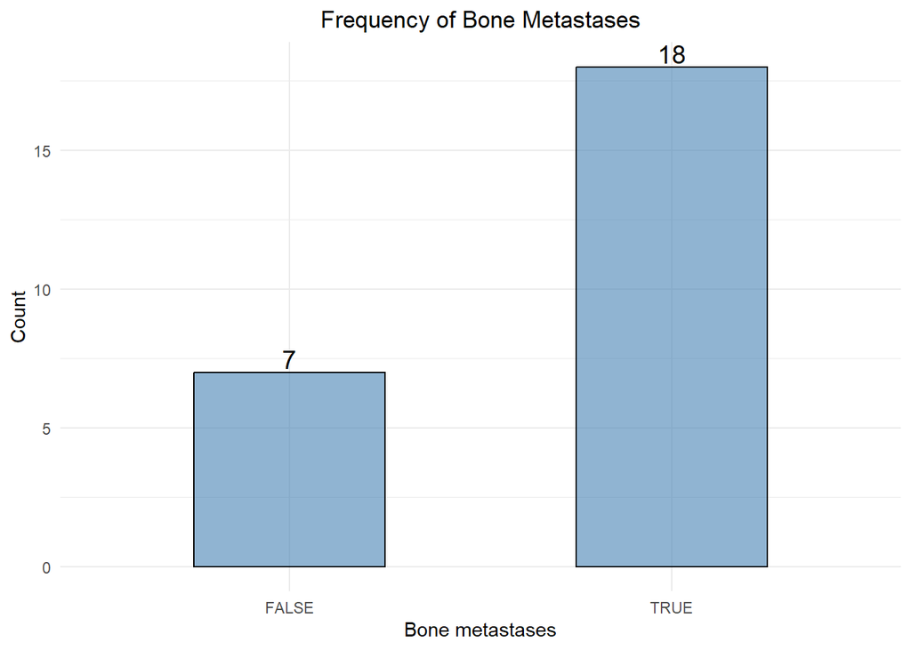

```r
high_ap_df |>
  ggplot(aes(x = bone_metastases)) +
  geom_bar(fill = "steelblue", alpha = 0.6, width = 0.5, color = "black") +
  geom_text(
    stat = "count",
    aes(label = ..count..),
    vjust = -0.2, # in the middle
    size = 5
  ) + # show counts
  labs(
    x = "Bone metastases",
    y = "Count",
    title = "Frequency of Bone Metastases"
  ) +
  theme_minimal()+
  theme(plot.title = element_text(hjust = 0.5) # keep titles in the middle
  )
```

A large fraction of high-AP patients exhibiting bone metastasis strengthens the interpretation that AP reflects tumor burden and metastatic progression.

## Survival of high-AP vs non-high-AP patients

To quantify risk, patients are stratified into high-risk (AP above the 95th percentile) and others, and compare survival curves (obtained by using the same km_fit function used earlier).

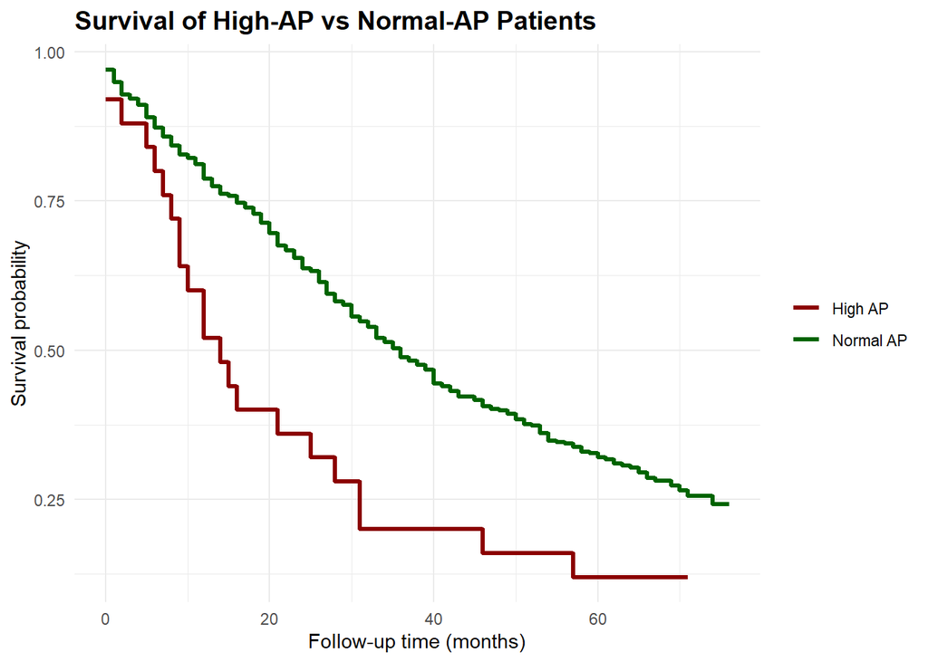

```r
full_df <- full_df |>
  mutate(
    ap_risk_group = ifelse(serum_prostatic_acid_phosphatase >= high_ap_threshold, "High AP", "Normal AP"),
    ap_risk_group = factor(ap_risk_group)
    )

km_ap <- km_fit(
  data = full_df,
  time_col = "follow_up_months",
  event_col = "is_alive",
  group_col = "ap_risk_group"
)

# draw surv curve

(km_ap |>
  ggplot(aes(x = time, y = surv, color = group)) +
  geom_step(size = 1.2) +
  labs(
    x = "Follow-up time (months)",
    y = "Survival probability",
    title = "Survival of High-AP vs Normal-AP Patients"
  ) +
  scale_color_manual(
    values = c(
      "High AP" = "darkred",
      "Normal AP" = "darkgreen"
    )
  ) +
  theme_minimal() +
  theme(
    plot.title = element_text(size = 14, face = "bold"),
    legend.title = element_blank()
  )) |> save_and_show("high_ap_comparison")
```

Patients with extremely elevated AP typically show sharply reduced survival, highlighting AP as a powerful prognostic biomarker.

## Interpretation

The exploration of outliers reveals distinct, clinically meaningful high-risk subgroups. These findings demonstrate that AP is a strong prognostic indicator and justify its inclusion in multivariable survival modeling as well as in clinical interpretation of treatment outcomes.

# Conclusion

In univariate Cox analyses, Age, AP, tumor size, bone metastasis, and clinical stage were strong adverse prognostic factors, whereas hemoglobin was protective. Among the treatment arms, only the 1.0 mg estrogen dose demonstrated a significantly reduced hazard of death relative to placebo. MAP showed no significant association with survival.

Overall, these results indicate that tumor burden biomarkers are the primary determinants of survival in this cohort, and that 1.0 mg estrogen provides a meaningful and independent therapeutic benefit.

# PCA Analysis

## Load library

```r
library("tidyverse")
library("broom")
source("99_proj_func.R") # custom functions and theme
```

## Load data

```r
load("../data/04_data_for_modelling.Rdata")
```

```r
df <- df_num |>
  select(where(is.numeric)) |>
  drop_na()
```

## Principal Component Analysis

### Numeric

```r
pca_fit <- df |>
  select(where(is.numeric)) |>
  scale() |>
  prcomp() # do PCA on scaled data
```

### Variance explanation

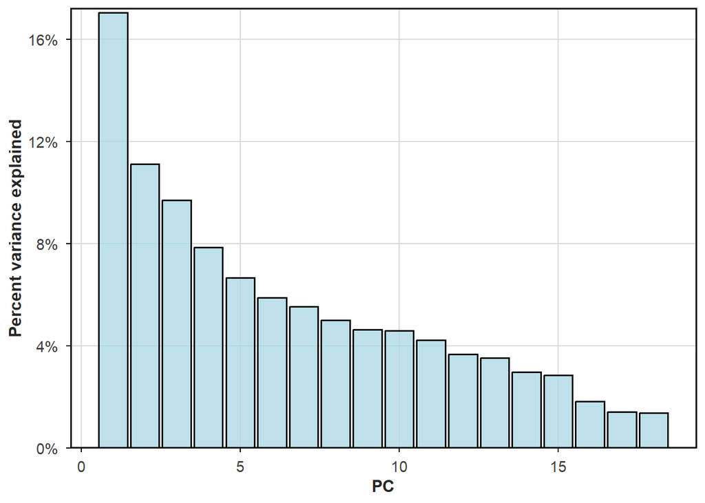

```r
pca_fit |>
  tidy(matrix = "eigenvalues") |>
  ggplot(aes(PC, percent)) +
  geom_col(fill = "lightblue",
           alpha = 0.8,
           color = "black") +
  scale_y_continuous(
    labels = scales::percent_format(),
    expand = expansion(mult = c(0, 0.01))
  ) +
  best_theme() +
  labs(y = "Percent variance explained")
```

## Conclusion

After further testing it has been decided that the PCA will not reveal any additional information than already covered in previous analysis.

```r
#render all notebooks
library("quarto")
qmds <- list.files(pattern = "\\.qmd$")
qmds <- qmds[qmds != "00_all.qmd"] #dont render current notebook i dont know if that would create a recursive loop
qmds <- qmds[qmds != "0X_background.qmd"]

for (qmd_document in qmds) {
  quarto_render(qmd_document,
                output_format = "html",
                execute_params = list(embed_resources = TRUE))}
```

[output not shown]

[output cut: 330 more lines]

[output not shown]

```r
#move them to res dir
html_names <- sub("\\.qmd$", ".html", qmds)

#move the files
if (!dir.exists("../results")){
  dir.create("../results", recursive = TRUE)}

# move each file
file.rename(html_names, file.path("../results", basename(html_names)))
```

```
[1] TRUE TRUE TRUE TRUE TRUE TRUE TRUE
```

```r
#Render the presentation as well
quarto_render("../doc/presentation.qmd")#presentation shouldnt be moved according to proj description
```

[output not shown]